# Master en Ciencia de Datos

# Tipologia y Ciclo de Vida de Datos

Autores: Anton Platonov y Taras Pavliv

Junio 2020

# 1 Eleccion del Dataset

Se escoge el “dataset” de calidad de vinos juntando los vinos blancos y rojos en primer lugar para intentar descubrir que propiedades influyen en la calidad del vino.  
Finalmente se intentara crear un sistema que pueda predecir si un vino será bueno o no en base a las propiedades químicas antes pasar por el proceso de cata y calificación humana. El “dataset” contiene 12 propiedades químicas numéricas con una nota final numérica del 1 al 10 representado su calidad. En este caso usaremos los vinos tanto blancos como los rojos por lo tanto añadiremos un valor “factor” para diferencia los tipos de vino. Para alcanzar el propósito descrito anteriormente seguiremos estos pasos:

1. Empezaremos con alisáis exploratorio básico del “dataset” que nos permita descubrir propiedades descriptivas de los datos y eliminar “outliers”.
2. En segundo Lugar, haremos un análisis estadístico para ver las correlaciones entre las propiedades químicas. Esto nos permitirá tener un “quick win” al ver como las variables se correlacionen entre si y afectan la calidad del vino.
3. En tercer lugar, intentaremos aplicar algoritmos de árboles de decisión que contienen componentes de regresión para entender las reglas de clasificación que hacen un vino de calidad.
4. Finalmente vamos a testear tanto los algoritmos de árboles de decisión como el algoritmo de KNN para comparar y decidir cual de ellos tiene la mejor capacidad de predicción de la calidad del vino según sus propiedades químicas.

Esta pieza de codigo nos importara todas la librerias que usaremos a lo largo de la PRAC

```r
# vuestro código
if(!require(Hmisc)){
  install.packages("Hmisc",repos = "http://cran.us.r-project.org")
  library("Hmisc")
}
if(!require(MASS)){
  install.packages("MASS",repos = "http://cran.us.r-project.org")
  library("MASS")
}

if(!require(fpp)){
  install.packages("fpp",repos = "http://cran.us.r-project.org")
  library("fpp")
}

if(!require(tseries)){
  install.packages("tseries",repos = "http://cran.us.r-project.org")
  library("tseries")
}

if(!require(agricolae)){
  install.packages("agricolae",repos = "http://cran.us.r-project.org")
  library("agricolae")
}

if(!require(corrplot)){
  install.packages("corrplot",repos = "http://cran.us.r-project.org")
  library("corrplot")
}

if(!require(ggplot2)){
  install.packages("ggplot2",repos = "http://cran.us.r-project.org")
  library(ggplot2)
}

if(!require(factoextra)){
  install.packages("factoextra",repos = "http://cran.us.r-project.org")
  library(factoextra)
}


if(!require(sbfc)){
  install.packages("sbfc",repos = "http://cran.us.r-project.org")
  library(sbfc)
}

if(!require(infotheo)){
  install.packages("infotheo",repos = "http://cran.us.r-project.org")
  library(infotheo)
}

if(!require(arules)){
  install.packages("arules",repos = "http://cran.us.r-project.org")
  library(arules)
}


if(!require(rpart)){
  install.packages("rpart",repos = "http://cran.us.r-project.org")
  library(rpart)
}

if(!require(plotly)){
  install.packages("plotly",repos = "http://cran.us.r-project.org")
  library(plotly)
}
if(!require(rpart.plot)){
  install.packages("rpart.plot",rpart.plot = "http://cran.us.r-project.org")
  library(rpart.plot)
}

if(!require(rattle)){
  install.packages("rattle",rpart.plot = "http://cran.us.r-project.org")
  library(rattle)
}

if(!require(RColorBrewer)){
  install.packages("RColorBrewer",rpart.plot = "http://cran.us.r-project.org")
  library(RColorBrewer)
}


if(!require(gmodels)){
    install.packages('gmodels', repos='http://cran.us.r-project.org')
    library(gmodels)
}
if(!require(partykit)){
    install.packages('partykit', repos='http://cran.us.r-project.org')
    library(partykit)
}
if(!require(ggplot2)){
    install.packages('ggplot2', repos='http://cran.us.r-project.org')
    library(ggplot2)
}

if(!require(magrittr)){
    install.packages('magrittr', repos='http://cran.us.r-project.org')
    library(magrittr)
}
if(!require(dplyr)){
    install.packages('dplyr', repos='http://cran.us.r-project.org')
    library(dplyr)
}

if(!require(C50)){
    install.packages('C50', repos='http://cran.us.r-project.org')
    library(C50)
}

if(!require(caret)){
    install.packages('caret', repos='http://cran.us.r-project.org')
    library(caret)
}
if(!require(rpart)){
    install.packages('rpart', repos='http://cran.us.r-project.org')
    library(rpart)
}

if(!require(rpart.plot)){
    install.packages('rpart.plot', repos='http://cran.us.r-project.org')
    library(rpart.plot)
}

if(!require(Hmisc)){
  install.packages("Hmisc",repos = "http://cran.us.r-project.org")
  library("Hmisc")
}
if(!require(MASS)){
  install.packages("MASS",repos = "http://cran.us.r-project.org")
  library("MASS")
}

if(!require(fpp)){
  install.packages("fpp",repos = "http://cran.us.r-project.org")
  library("fpp")
}

if(!require(tseries)){
  install.packages("tseries",repos = "http://cran.us.r-project.org")
  library("tseries")
}

if(!require(agricolae)){
  install.packages("agricolae",repos = "http://cran.us.r-project.org")
  library("agricolae")
}

if(!require(corrplot)){
  install.packages("corrplot",repos = "http://cran.us.r-project.org")
  library("corrplot")
}

if(!require(ggplot2)){
  install.packages("ggplot2",repos = "http://cran.us.r-project.org")
  library(ggplot2)
}

if(!require(factoextra)){
  install.packages("factoextra",repos = "http://cran.us.r-project.org")
  library(factoextra)
}


if(!require(sbfc)){
  install.packages("sbfc",repos = "http://cran.us.r-project.org")
  library(sbfc)
}

if(!require(infotheo)){
  install.packages("infotheo",repos = "http://cran.us.r-project.org")
  library(infotheo)
}

if(!require(infotheo)){
  install.packages("infotheo",repos = "http://cran.us.r-project.org")
  library(infotheo)
}
if(!require(randomForest)){
  install.packages("randomForest",repos = "http://cran.us.r-project.org")
  library(randomForest)
}
if(!require(class)){
  install.packages("class",repos = "http://cran.us.r-project.org")
  library(class)
}

if(!require(fpc)){
  install.packages("fpc",repos = "http://cran.us.r-project.org")
  library(fpc)
}

if(!require(factoextra)){
  install.packages("factoextra",repos = "http://cran.us.r-project.org")
  library("factoextra")
}
```

# 2 Selección de las variables y Limpieza de Datos:

Descargamos 2 “datesets” de calidad de vino rojo y blanco y los unimos a través de la variable “Type” que será categórica con valores “B” y “R”.

```r
VinoR <- read.csv('http://archive.ics.uci.edu/ml/machine-learning-databases/wine-quality/winequality-red.csv',sep=";",stringsAsFactors = FALSE, header = TRUE)
VinoB <- read.csv('http://archive.ics.uci.edu/ml/machine-learning-databases/wine-quality/winequality-white.csv',sep=";",stringsAsFactors = FALSE, header = TRUE)


VinoR$Type = "B"
VinoB$Type = "R"

names(VinoR)
```

```
##  [1] "fixed.acidity"        "volatile.acidity"     "citric.acid"
##  [4] "residual.sugar"       "chlorides"            "free.sulfur.dioxide"
##  [7] "total.sulfur.dioxide" "density"              "pH"
## [10] "sulphates"            "alcohol"              "quality"
## [13] "Type"
```

```r
names(VinoB)
```

```
##  [1] "fixed.acidity"        "volatile.acidity"     "citric.acid"
##  [4] "residual.sugar"       "chlorides"            "free.sulfur.dioxide"
##  [7] "total.sulfur.dioxide" "density"              "pH"
## [10] "sulphates"            "alcohol"              "quality"
## [13] "Type"
```

```r
str(VinoR)
```

```
## 'data.frame':    1599 obs. of  13 variables:
##  $ fixed.acidity       : num  7.4 7.8 7.8 11.2 7.4 7.4 7.9 7.3 7.8 7.5 ...
##  $ volatile.acidity    : num  0.7 0.88 0.76 0.28 0.7 0.66 0.6 0.65 0.58 0.5 ...
##  $ citric.acid         : num  0 0 0.04 0.56 0 0 0.06 0 0.02 0.36 ...
##  $ residual.sugar      : num  1.9 2.6 2.3 1.9 1.9 1.8 1.6 1.2 2 6.1 ...
##  $ chlorides           : num  0.076 0.098 0.092 0.075 0.076 0.075 0.069 0.065 0.073 0.071 ...
##  $ free.sulfur.dioxide : num  11 25 15 17 11 13 15 15 9 17 ...
##  $ total.sulfur.dioxide: num  34 67 54 60 34 40 59 21 18 102 ...
##  $ density             : num  0.998 0.997 0.997 0.998 0.998 ...
##  $ pH                  : num  3.51 3.2 3.26 3.16 3.51 3.51 3.3 3.39 3.36 3.35 ...
##  $ sulphates           : num  0.56 0.68 0.65 0.58 0.56 0.56 0.46 0.47 0.57 0.8 ...
##  $ alcohol             : num  9.4 9.8 9.8 9.8 9.4 9.4 9.4 10 9.5 10.5 ...
##  $ quality             : int  5 5 5 6 5 5 5 7 7 5 ...
##  $ Type                : chr  "B" "B" "B" "B" ...
```

```r
str(VinoB)
```

```
## 'data.frame':    4898 obs. of  13 variables:
##  $ fixed.acidity       : num  7 6.3 8.1 7.2 7.2 8.1 6.2 7 6.3 8.1 ...
##  $ volatile.acidity    : num  0.27 0.3 0.28 0.23 0.23 0.28 0.32 0.27 0.3 0.22 ...
##  $ citric.acid         : num  0.36 0.34 0.4 0.32 0.32 0.4 0.16 0.36 0.34 0.43 ...
##  $ residual.sugar      : num  20.7 1.6 6.9 8.5 8.5 6.9 7 20.7 1.6 1.5 ...
##  $ chlorides           : num  0.045 0.049 0.05 0.058 0.058 0.05 0.045 0.045 0.049 0.044 ...
##  $ free.sulfur.dioxide : num  45 14 30 47 47 30 30 45 14 28 ...
##  $ total.sulfur.dioxide: num  170 132 97 186 186 97 136 170 132 129 ...
##  $ density             : num  1.001 0.994 0.995 0.996 0.996 ...
##  $ pH                  : num  3 3.3 3.26 3.19 3.19 3.26 3.18 3 3.3 3.22 ...
##  $ sulphates           : num  0.45 0.49 0.44 0.4 0.4 0.44 0.47 0.45 0.49 0.45 ...
##  $ alcohol             : num  8.8 9.5 10.1 9.9 9.9 10.1 9.6 8.8 9.5 11 ...
##  $ quality             : int  6 6 6 6 6 6 6 6 6 6 ...
##  $ Type                : chr  "R" "R" "R" "R" ...
```

```r
dim(VinoR)
```

```
## [1] 1599   13
```

```r
dim(VinoB)
```

```
## [1] 4898   13
```

```r
VinoRB  <- rbind(VinoR, VinoB)

set.seed(1)
VinoRB <- VinoRB[sample(nrow(VinoRB)),]
```

```r
str(VinoRB)
```

```
## 'data.frame':    6497 obs. of  13 variables:
##  $ fixed.acidity       : num  8.9 7.8 7.1 7.1 7.2 6.6 7.2 11.5 6.6 6.7 ...
##  $ volatile.acidity    : num  0.38 0.21 0.22 0.17 0.53 0.23 0.29 0.18 0.56 0.34 ...
##  $ citric.acid         : num  0.4 0.34 0.33 0.4 0.13 0.3 0.4 0.51 0.15 0.43 ...
##  $ residual.sugar      : num  2.2 11.9 2.8 14.6 2 ...
##  $ chlorides           : num  0.068 0.039 0.033 0.047 0.058 0.051 0.024 0.104 0.037 0.041 ...
##  $ free.sulfur.dioxide : num  12 55 48 47 18 33 56 4 38 29 ...
##  $ total.sulfur.dioxide: num  28 140 153 156 22 118 177 23 157 114 ...
##  $ density             : num  0.995 0.996 0.99 0.999 0.996 ...
##  $ pH                  : num  3.27 3.02 3.15 3.34 3.21 3.04 3.04 3.28 3.28 3.23 ...
##  $ sulphates           : num  0.75 0.31 0.38 0.78 0.68 0.54 0.32 0.97 0.52 0.44 ...
##  $ alcohol             : num  12.6 10.3 12.7 9.1 9.9 9 11.5 10.1 9.4 12.6 ...
##  $ quality             : int  7 6 7 6 6 6 6 6 5 6 ...
##  $ Type                : chr  "B" "R" "R" "R" ...
```

```r
unique(VinoRB$quality)
```

```
## [1] 7 6 5 8 4 3 9
```

Nos damos cuenta de que tienen el mismo formato los 2 “dataset” de vinos rojos y vinos blancos. Además, vemos que todas las columnas son de tipo NUM menos la de la calidad del vino que sería del tipo INT que es la calidad del vino probablemente del 1 al 10 mirando los valores distintos

Seguidamente exploramos si hay valores blancos

```r
unique(is.na(VinoRB))
```

```
##      fixed.acidity volatile.acidity citric.acid residual.sugar chlorides
## 1017         FALSE            FALSE       FALSE          FALSE     FALSE
##      free.sulfur.dioxide total.sulfur.dioxide density    pH sulphates
## 1017               FALSE                FALSE   FALSE FALSE     FALSE
##      alcohol quality  Type
## 1017   FALSE   FALSE FALSE
```

Podemos ver que no hay valores blancos

# 3 Análisis Exploratorio:

Dentro del análisis exploratorio vamos a comprobar la distribución de los datos, procederemos a la identificación de los “outliers” y finalmente analizaremos las correlaciones entre las variables.

## 3.1 Identificacion de distribucion y Normalizcion de los Datos:

Dibujamos los histogramas y los boxplot de las variables para poder identificar las distribuciones y sus outliers.

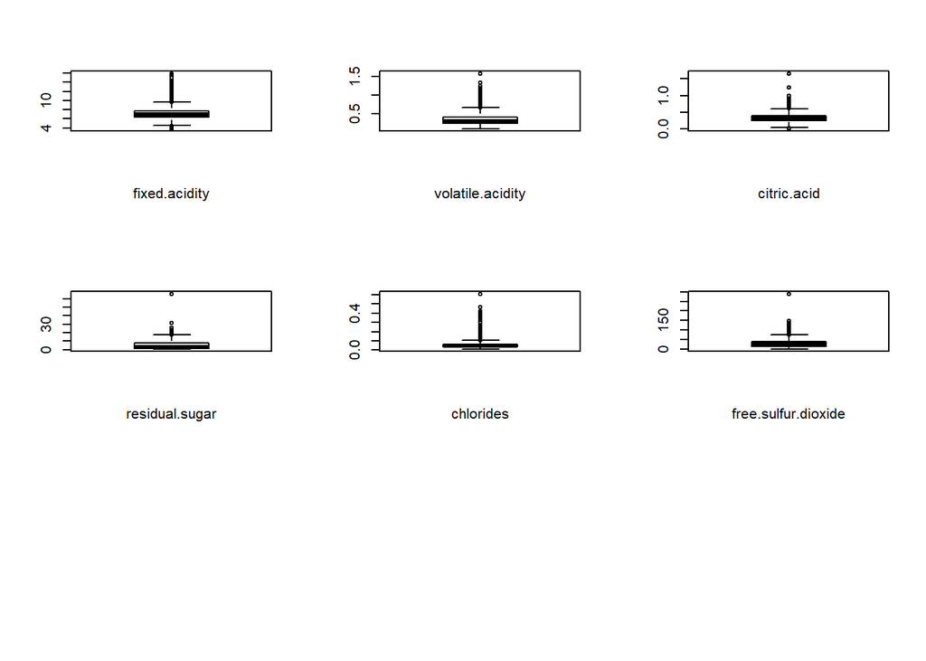

```r
par(mfrow=c(3,3))
for (i in c(1,2,3,4,5,6))
{
  boxplot(VinoRB[,i],xlab=names(VinoR)[i])
}

par(mfrow=c(3,3))
```

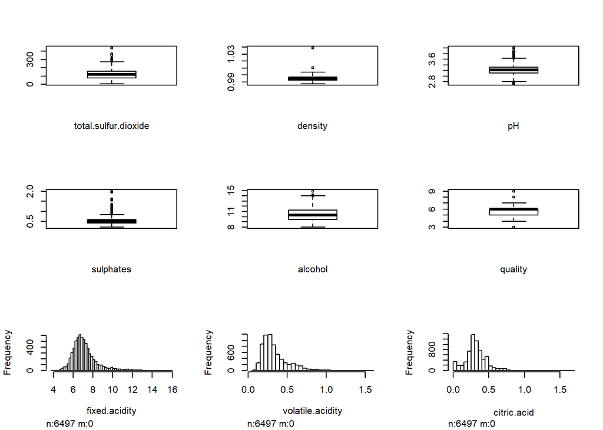

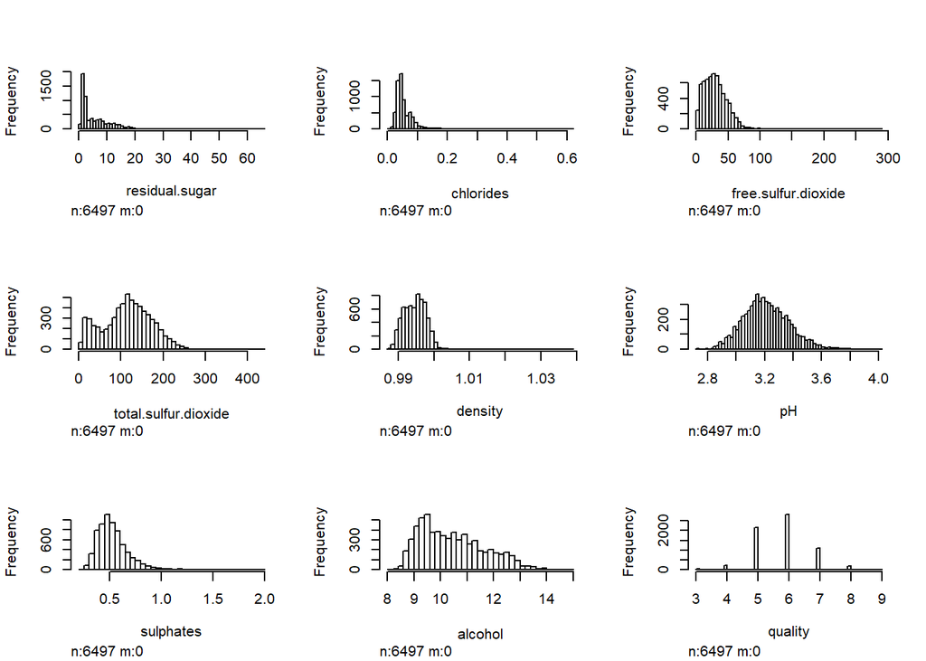

```r
for (i in c(7,8,9,10,11,12))
{
  boxplot(VinoRB[,i],xlab=names(VinoR)[i])
}


hist.data.frame(VinoRB[,1:12])
```

Miramos las distribuciones de los datos de manera visual y nos damos cuenta de que la mayoría de los datos no sigue una distribución normal. De esta manera los “boxplot” nos indican muchos potenciales outliers pero estos podrían ser datos que representan de manera ajustada el dataset, puesto que los “boxplot” asumen la una cierta simetría en las colas de los histogramas de los datos, especialmente cuando la distribución esta inclinada en un lado en particular.

Asumimos esta informacion segun nos explican en el articulo Vandervieren, Ellen & Hubert, Mia. (2004). An adjusted boxplot for skewed distributions.

Además, si hacemos el test de normalidad con shapiro nos damos cuenta que ninguna de las variables es normal ya que en todos los casos el P-values es menor que 0,05 para todas las columnas. De esta manera podemos rechazar que la muestra proviene de un dataset de distribución normal.

```r
lshap <- lapply(VinoRB[1:5000,1:11], shapiro.test)

lres <- sapply(lshap, `[`, c("statistic","p.value"))

lres
```

```
##           fixed.acidity volatile.acidity citric.acid  residual.sugar
## statistic 0.8753346     0.8762748        0.9634979    0.82203
## p.value   5.423751e-53  7.354601e-53     9.191141e-34 2.099194e-59
##           chlorides    free.sulfur.dioxide total.sulfur.dioxide
## statistic 0.6120584    0.9330021           0.9834502
## p.value   9.288559e-75 1.039357e-42        9.423006e-24
##           density      pH          sulphates    alcohol
## statistic 0.9628138    0.9920373   0.8969445    0.9543243
## p.value   5.082632e-34 3.83668e-16 1.019707e-49 6.139638e-37
```

Dado que en el histograma anterior veíamos que era distribuciones “parecidas a las normales” pero descentralizadas. Por lo tanto, usamos la transformación box-cox para normalizar los datos.

Nótese que vamos a escoger una lambda optima directamente con la función “boxcos.lambda” para cada una de las columnas

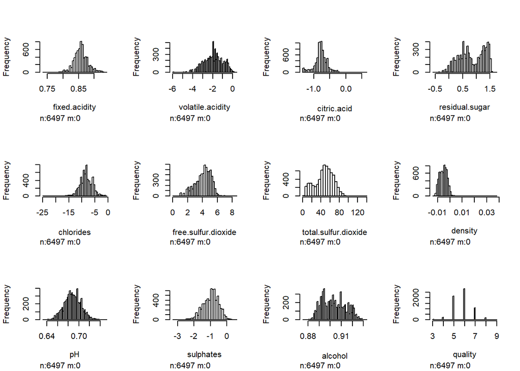

```r
lshap <- lapply(VinoRB[,1:11], BoxCox.lambda)
VinoRB_trasformed <- VinoRB


for (i in c(1,2,3,4,5,6,7,8,9,10,11))
{
   VinoRB_trasformed [,i]<- BoxCox(VinoRB[,i],lshap[[i]])
}


hist.data.frame(VinoRB_trasformed[,1:12])
```

```r
lshap <- lapply(VinoRB_trasformed[1:5000,1:11], shapiro.test)
lres <- sapply(lshap, `[`, c("p.value"))
lres
```

```
## $fixed.acidity.p.value
## [1] 5.408709e-22
##
## $volatile.acidity.p.value
## [1] 3.401112e-21
##
## $citric.acid.p.value
## [1] 1.022186e-34
##
## $residual.sugar.p.value
## [1] 1.499893e-39
##
## $chlorides.p.value
## [1] 2.270104e-22
##
## $free.sulfur.dioxide.p.value
## [1] 1.569643e-30
##
## $total.sulfur.dioxide.p.value
## [1] 6.043474e-27
##
## $density.p.value
## [1] 4.728988e-33
##
## $pH.p.value
## [1] 0.007527938
##
## $sulphates.p.value
## [1] 1.750093e-16
##
## $alcohol.p.value
## [1] 2.995842e-29
```

Al hacer la transformación no se consigue normalizar los datos. La variable que más se acercaría a una distribución normal seria la variable PH con el P-value más grande a pesar de que este no llegue a ser superior a alpha.

Por este motivo probamos con otros tipos de transformaciones como “square root”, logaritm10 y log2. que potencialmente nos servirán para transformar de distribuciones de datos exponenciales/logarítmicas en normales, es decir centrarlas.

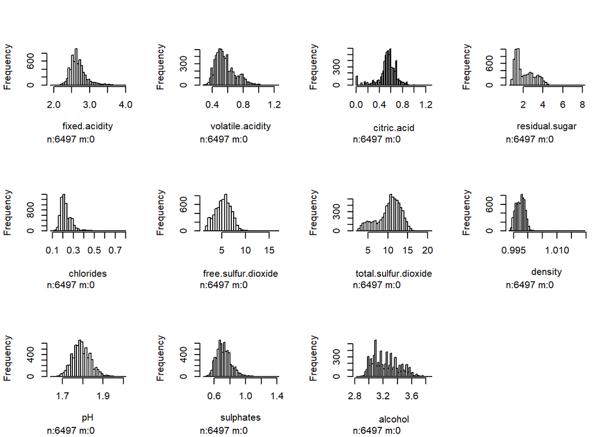

```r
VinoRB_trasformedsqrt <- VinoRB
VinoRB_trasformedlog10 <- VinoRB
VinoRB_trasformedlog2 <- VinoRB

for (i in c(1,2,3,4,5,6,7,8,9,10,11))
{
   VinoRB_trasformedsqrt [,i]<- sqrt(VinoRB[,i])
}

for (i in c(1,2,3,4,5,6,7,8,9,10,11))
{
   VinoRB_trasformedlog10 [,i]<- log10(VinoRB[,i])
}

for (i in c(1,2,3,4,5,6,7,8,9,10,11))
{
   VinoRB_trasformedlog2 [,i]<- log2(VinoRB[,i])
}

hist.data.frame(VinoRB_trasformedsqrt[,1:11])
```

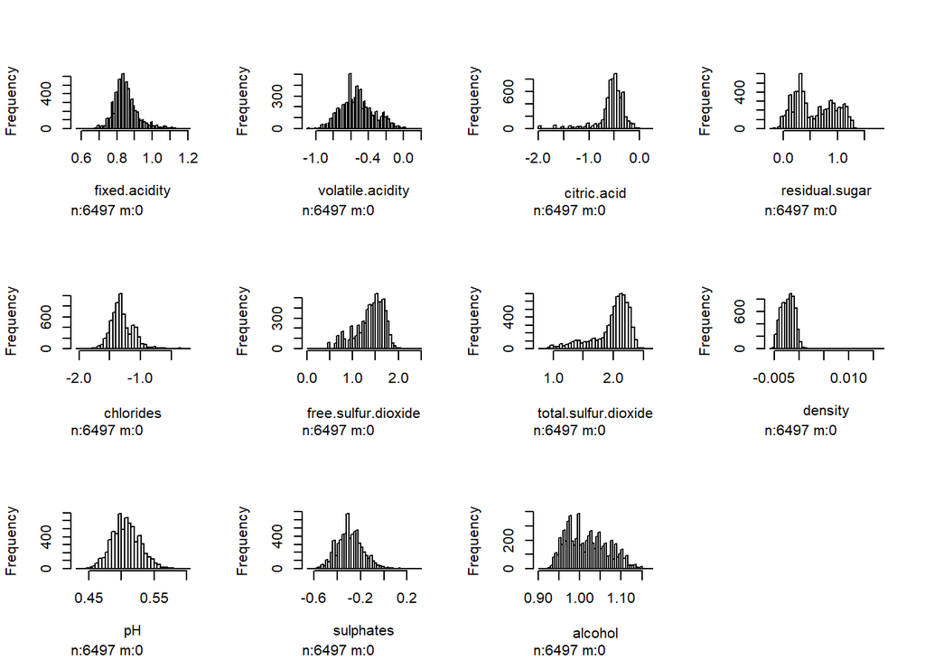

```r
hist.data.frame(VinoRB_trasformedlog10[,1:11])
```

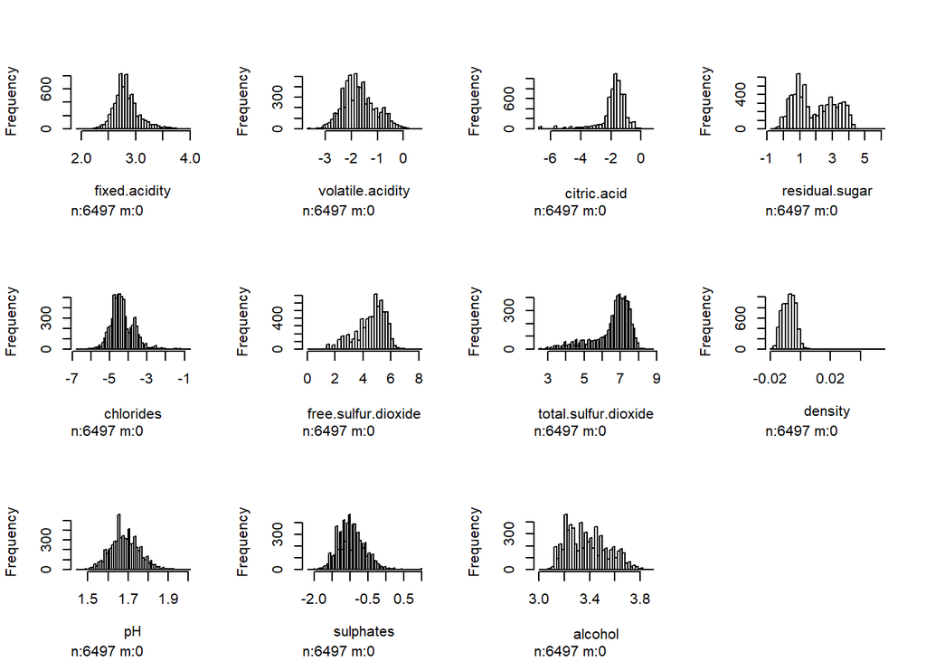

```r
hist.data.frame(VinoRB_trasformedlog2[,1:11])
```

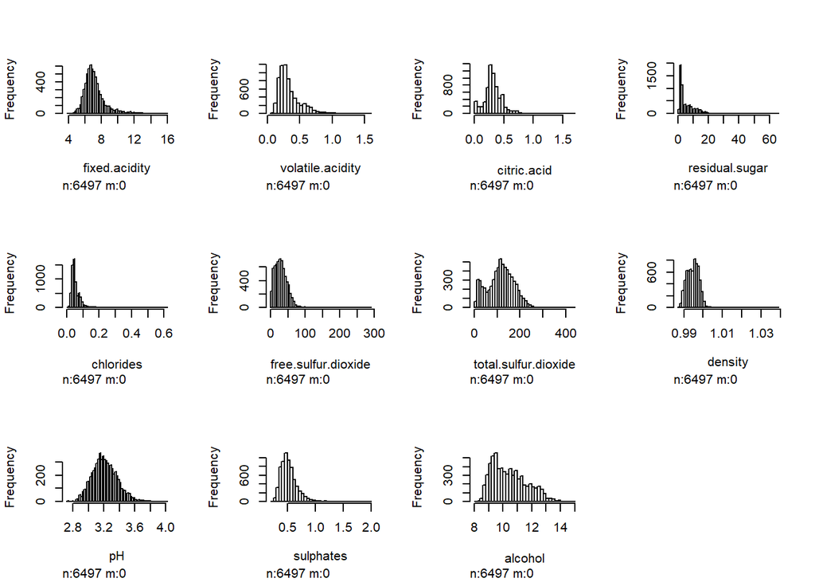

```r
hist.data.frame(VinoRB[,1:11])
```

```r
"*************************** Pvalues con transformacion SQRT"
```

```
## [1] "*************************** Pvalues con transformacion SQRT"
```

```r
lshap2 <- lapply(VinoRB_trasformedsqrt[1:5000,1:11], shapiro.test)
lres2 <- sapply(lshap2, `[`, c("p.value"))
lres2
```

```
## $fixed.acidity.p.value
## [1] 9.582565e-46
##
## $volatile.acidity.p.value
## [1] 1.031736e-38
##
## $citric.acid.p.value
## [1] 4.464634e-49
##
## $residual.sugar.p.value
## [1] 4.104038e-49
##
## $chlorides.p.value
## [1] 2.796534e-58
##
## $free.sulfur.dioxide.p.value
## [1] 5.296567e-18
##
## $total.sulfur.dioxide.p.value
## [1] 3.192054e-36
##
## $density.p.value
## [1] 8.994214e-34
##
## $pH.p.value
## [1] 1.592078e-12
##
## $sulphates.p.value
## [1] 8.190007e-36
##
## $alcohol.p.value
## [1] 1.282692e-34
```

```r
"*************************** Pvalues con transformacion log10"
```

```
## [1] "*************************** Pvalues con transformacion log10"
```

```r
lshap3 <- lapply(VinoRB_trasformedlog10[1:5000,1:11], shapiro.test)
lres3 <- sapply(lshap3, `[`, c("p.value"))

lres3
```

```
## $fixed.acidity.p.value
## [1] 1.305832e-37
##
## $volatile.acidity.p.value
## [1] 2.384659e-19
##
## $citric.acid.p.value
## [1] NaN
##
## $residual.sugar.p.value
## [1] 1.934421e-40
##
## $chlorides.p.value
## [1] 4.549131e-36
##
## $free.sulfur.dioxide.p.value
## [1] 5.50325e-38
##
## $total.sulfur.dioxide.p.value
## [1] 2.421643e-54
##
## $density.p.value
## [1] 1.577801e-33
##
## $pH.p.value
## [1] 7.742259e-09
##
## $sulphates.p.value
## [1] 1.510328e-18
##
## $alcohol.p.value
## [1] 1.726622e-32
```

```r
"*************************** Pvalues con transformacion log2"
```

```
## [1] "*************************** Pvalues con transformacion log2"
```

```r
lshap4 <- lapply(VinoRB_trasformedlog2[1:5000,1:11], shapiro.test)
lres4 <- sapply(lshap4, `[`, c("p.value"))

lres4
```

```
## $fixed.acidity.p.value
## [1] 1.305832e-37
##
## $volatile.acidity.p.value
## [1] 2.384659e-19
##
## $citric.acid.p.value
## [1] NaN
##
## $residual.sugar.p.value
## [1] 1.934421e-40
##
## $chlorides.p.value
## [1] 4.549131e-36
##
## $free.sulfur.dioxide.p.value
## [1] 5.50325e-38
##
## $total.sulfur.dioxide.p.value
## [1] 2.421643e-54
##
## $density.p.value
## [1] 1.577801e-33
##
## $pH.p.value
## [1] 7.742259e-09
##
## $sulphates.p.value
## [1] 1.510328e-18
##
## $alcohol.p.value
## [1] 1.726622e-32
```

## 3.2 Identificación de Outliers:

Por el motivo descrito anteriormente escogemos la variable PH para dibujar el boxplot e identificar potenciales outliers. Por lo tanto, dibujamos el boxplot

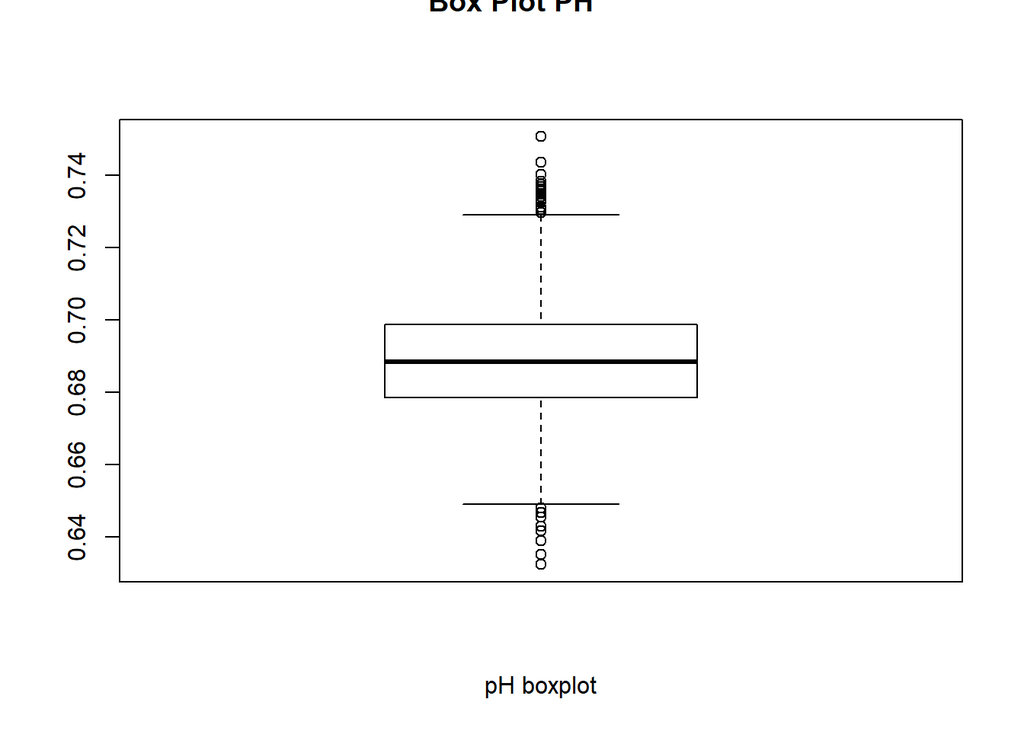

```r
VinoRB_trasformedboc_cox <- VinoRB

VinoRB_trasformedboc_cox$pH<- BoxCox(VinoRB$pH,BoxCox.lambda(VinoRB$pH))

boxplot(VinoRB_trasformed$pH, xlab = "pH boxplot")
title("Box Plot PH" , outer=TRUE)
```

En la gráfica superior podemos ver que asumiendo la normalidad de los datos habria potenciales outliers. Por lo tanto, probamos de quitar valores que superen el 99% de valores acumulados y el 1%.

Puesto que en este ejercicio nos queremos focalizar en analizar cuáles son las características que diferencian buenos vinos de los malos analizamos con un histograma los potenciales valores que seleccionaremos (menor que 1% y mayor que 99%) desde el punto de vista de la calidad. Esto es muy importante ya que los valores muy grandes o los valores muy pequeños podría tener una conexión con la calidad. y de esta manera al eliminar outliers estaríamos desequilibrando nuestro “dataset”.

Por lo tanto, al final hacemos también una comparación entre histogramas de calidad para asegurarnos que eliminamos de manera equitativa entre todas las etiquetas de calidad.

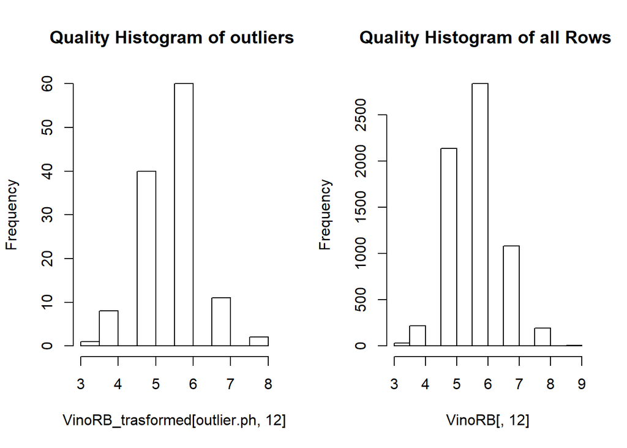

```r
VinoRB_trasformed.ph <- quantile(VinoRB_trasformed$pH, probs = c(0.01, 0.99))

outlier.ph <- VinoRB_trasformed$pH < VinoRB_trasformed.ph[1] | VinoRB_trasformed$pH > VinoRB_trasformed.ph[2]



VinoRB_filtered <- VinoRB[!outlier.ph, ]
par(mfrow=c(1,2))
hist(VinoRB_trasformed[outlier.ph, 12], main="Quality Histogram of outliers ")
hist(VinoRB[, 12], main="Quality Histogram of all Rows ")
```

```r
nrow(VinoRB_trasformed)-nrow(VinoRB_filtered)
```

```
## [1] 122
```

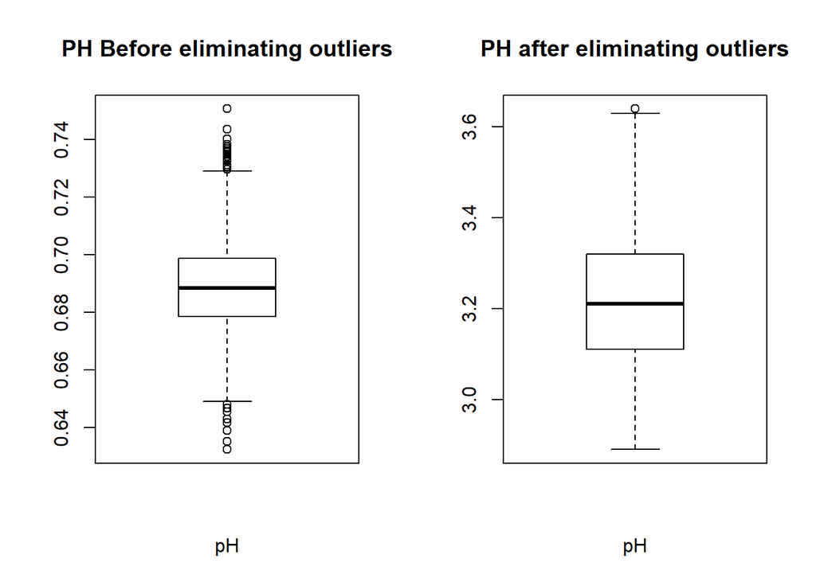

```r
boxplot(VinoRB_trasformed$pH, xlab = "pH",  main="PH Before eliminating outliers")
boxplot(VinoRB_filtered$pH, xlab = "pH",  main="PH after eliminating outliers")
```

Aparte de los análisis estadísticos de los datos para determinar outliers vamos a hacer un análisis lógico conceptual para determinar posibles errores de medición.

Vamos a hacer un box-plot para todas las variables teniendo en cuenta su calidad. De esta manera podemos ver si estaríamos observado casos anormales que pudieran tener alguna relación con la calidad. Es decir que los outliers en algunas propiedades químicas podrían explicar su impacto positivo o negativo en la calidad.

Esto podemos comprobar la hipótesis anterior ya que la variable de calidad sigue una distribución normal tanto en vinos blancos como en vinos rojos. Indicando así que los extremos (vinos muy malos y buenos) representan una pequeña porción del dataset.

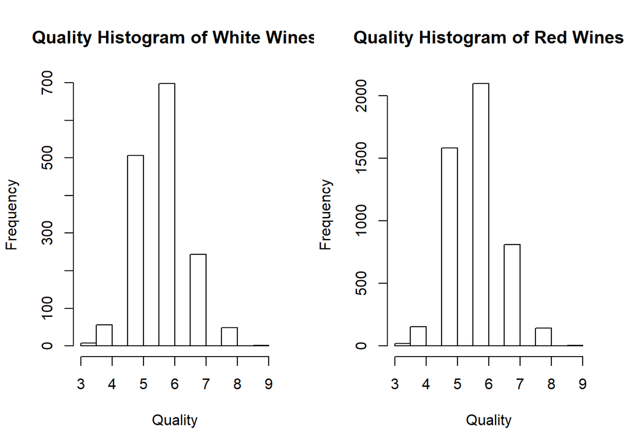

```r
par(mfrow=c(1,2))
hist(VinoRB[which(VinoRB_filtered$Type=="B"), 12], main="Quality Histogram of White Wines", xlab="Quality",)
hist(VinoRB[which(VinoRB_filtered$Type=="R"), 12], main="Quality Histogram of Red Wines", xlab="Quality",)
```

Para seguir con el análisis vamos a dibujar los box-plot de los vinos rojos y los vinos blancos por separado ya que probablemente las propiedades de los vinos blancos y los rojos son distintas. Algo que podemos ver comparando los vinos blancos y los rojos con el mismo box-plot.

Es importante destacar que primero vamos a analizar que outliers identificamos y luego quitarlos.

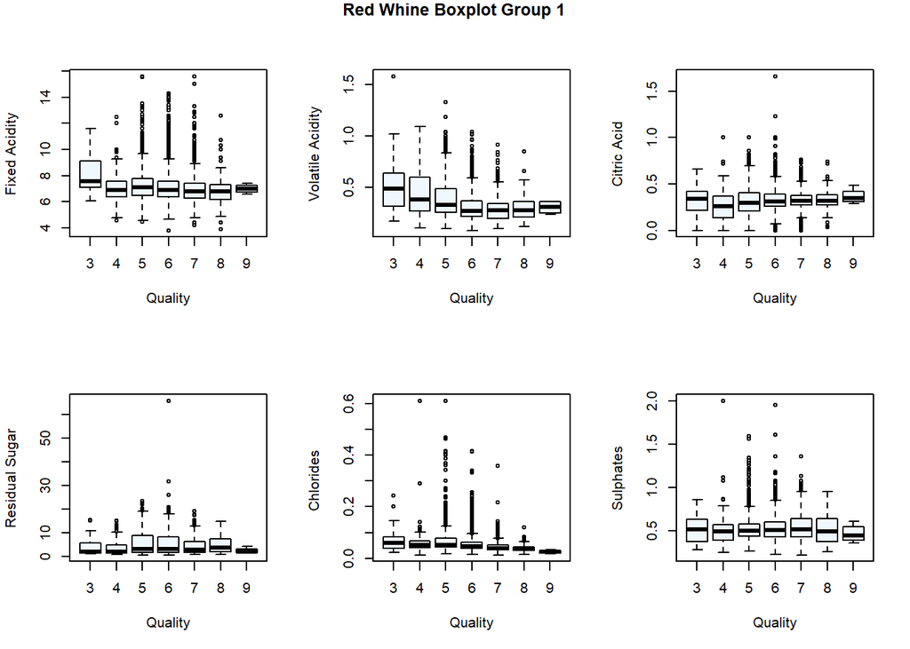

```r
par(mfrow=c(2,3))
boxplot(fixed.acidity ~ quality, data=VinoRB[which(VinoRB_filtered$Type=="R"), ],col=("aliceblue"),  xlab="Quality", ylab="Fixed Acidity")
boxplot(volatile.acidity ~ quality, data=VinoRB[which(VinoRB_filtered$Type=="R"), ],col=("aliceblue"), xlab="Quality", ylab="Volatile Acidity")
boxplot(citric.acid ~ quality, data=VinoRB[which(VinoRB_filtered$Type=="R"), ],col=("aliceblue"), xlab="Quality", ylab="Citric Acid")
boxplot(residual.sugar ~ quality, data=VinoRB[which(VinoRB_filtered$Type=="R"), ],col=("aliceblue"), xlab="Quality", ylab="Residual Sugar")
boxplot(chlorides ~ quality, data=VinoRB[which(VinoRB_filtered$Type=="R"), ],col=("aliceblue"), xlab="Quality", ylab="Chlorides ")
boxplot(sulphates ~ quality, data=VinoRB[which(VinoRB_filtered$Type=="R"), ],col=("aliceblue"), xlab="Quality", ylab="Sulphates")
par(oma=c(0,0,1,0))
title("Red Whine Boxplot Group 1" , outer=TRUE)
```

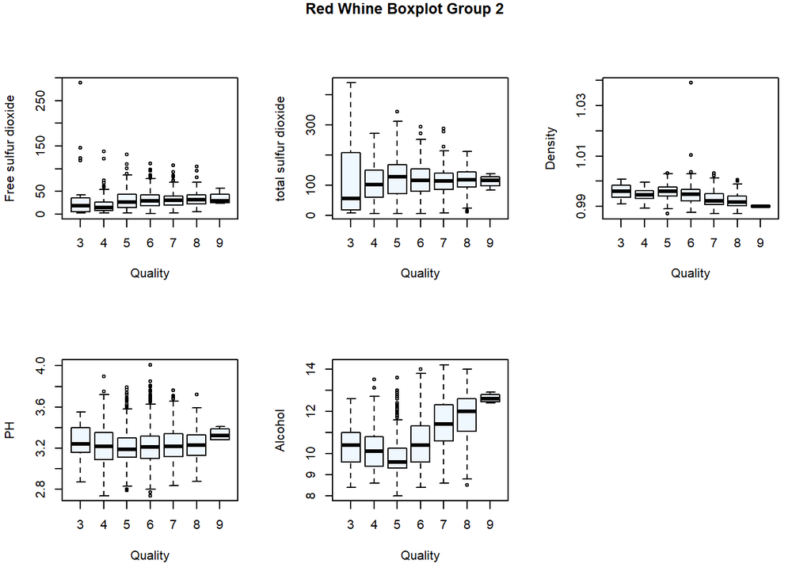

```r
par(mfrow=c(2,3))
boxplot(free.sulfur.dioxide ~ quality, data=VinoRB[which(VinoRB_filtered$Type=="R"), ],col=("aliceblue") , xlab="Quality", ylab="Free sulfur dioxide")
boxplot(total.sulfur.dioxide ~ quality, data=VinoRB[which(VinoRB_filtered$Type=="R"), ],col=("aliceblue") , xlab="Quality", ylab="total sulfur dioxide")
boxplot(density ~ quality, data=VinoRB[which(VinoRB_filtered$Type=="R"), ],col=("aliceblue"), xlab="Quality", ylab="Density")
boxplot(pH ~ quality, data=VinoRB[which(VinoRB_filtered$Type=="R"), ],col=("aliceblue"), xlab="Quality", ylab="PH")
boxplot(alcohol ~ quality, data=VinoRB[which(VinoRB_filtered$Type=="R"), ],col=("aliceblue"), xlab="Quality", ylab="Alcohol")
par(oma=c(0,0,1,0))
title("Red Whine Boxplot Group 2" , outer=TRUE)
```

Para los Vinos Rojos

Grupo de químicos referidos en la gráfica Group 1

Grupo de químicos referidos en la gráfica Group 2

• En Cuanto a Free Surfur dioxide vemos que la calidad incrementa cuando hay menos variación por lo tanto no vamos a tocar estos valores. Excepto el valor mayo de 250 ya que está muy lejos de los demás grupos y es un valor único. • En Cuanto a Total Surfur dióxido vemos que la variación está totalmente relacionada con la calidad y no vemos valores extremadamente alejados • En Cuanto a la densidad vemos que hay un único valor extremo por encima de 1.03 que podría ser cause de un error de medición. por lo tanto, lo consideraremos como outlier y lo quitaremos • En cuanto al PH y al alcohol podemos ver que la calidad de los vinos es superior cuando hay menos variación y la media es más alta. Por lo tanto, no consideraremos a categorizar ningún punto como outlier.

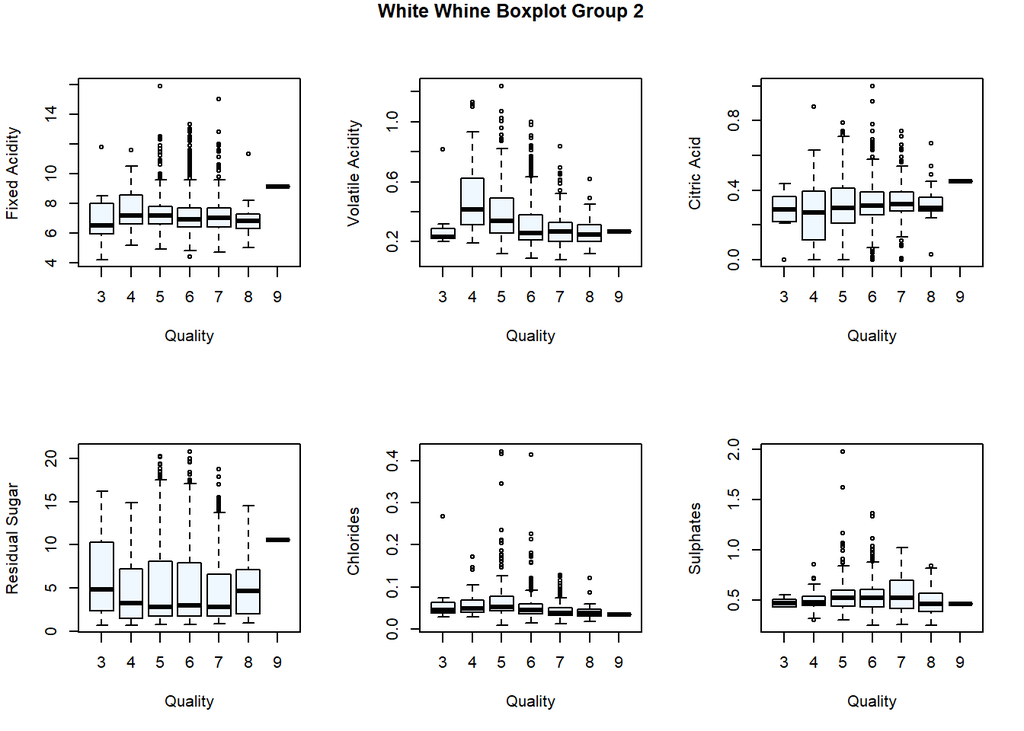

```r
par(mfrow=c(2,3))
boxplot(fixed.acidity ~ quality, data=VinoRB[which(VinoRB_filtered$Type=="B"), ],col=("aliceblue"),  xlab="Quality", ylab="Fixed Acidity")
boxplot(volatile.acidity ~ quality, data=VinoRB[which(VinoRB_filtered$Type=="B"), ],col=("aliceblue"), xlab="Quality", ylab="Volatile Acidity")
boxplot(citric.acid ~ quality, data=VinoRB[which(VinoRB_filtered$Type=="B"), ],col=("aliceblue"), xlab="Quality", ylab="Citric Acid")
boxplot(residual.sugar ~ quality, data=VinoRB[which(VinoRB_filtered$Type=="B"), ],col=("aliceblue"), xlab="Quality", ylab="Residual Sugar")
boxplot(chlorides ~ quality, data=VinoRB[which(VinoRB_filtered$Type=="B"), ],col=("aliceblue"), xlab="Quality", ylab="Chlorides ")
boxplot(sulphates ~ quality, data=VinoRB[which(VinoRB_filtered$Type=="B"), ],col=("aliceblue"), xlab="Quality", ylab="Sulphates")
par(oma=c(0,0,1,0))
title("White Whine Boxplot Group 2" , outer=TRUE)
```

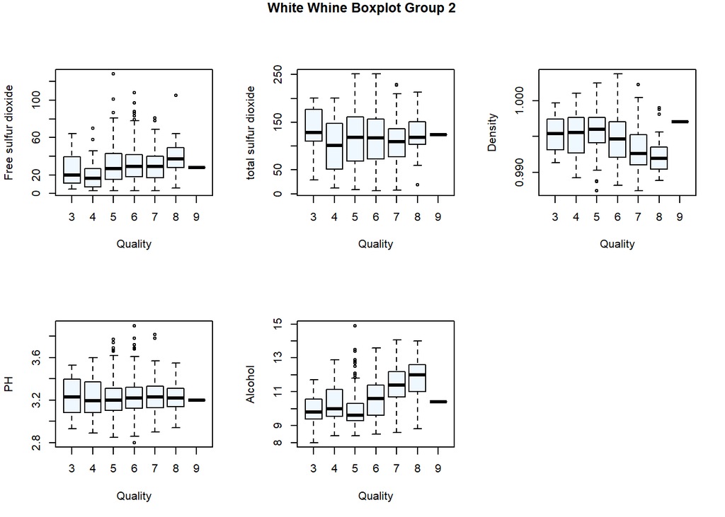

```r
par(mfrow=c(2,3))
boxplot(free.sulfur.dioxide ~ quality, data=VinoRB[which(VinoRB_filtered$Type=="B"), ],col=("aliceblue") , xlab="Quality", ylab="Free sulfur dioxide")
boxplot(total.sulfur.dioxide ~ quality, data=VinoRB[which(VinoRB_filtered$Type=="B"), ],col=("aliceblue") , xlab="Quality", ylab="total sulfur dioxide")
boxplot(density ~ quality, data=VinoRB[which(VinoRB_filtered$Type=="B"), ],col=("aliceblue"), xlab="Quality", ylab="Density")
boxplot(pH ~ quality, data=VinoRB[which(VinoRB_filtered$Type=="B"), ],col=("aliceblue"), xlab="Quality", ylab="PH")
boxplot(alcohol ~ quality, data=VinoRB[which(VinoRB_filtered$Type=="B"), ],col=("aliceblue"), xlab="Quality", ylab="Alcohol")
par(oma=c(0,0,1,0))
title("White Whine Boxplot Group 2" , outer=TRUE)
```

Para los Vinos Blancos

Grupo de químicos referidos en la gráfica Group 1 Podemos ver que hay una clara relación entre la dispersión y la calidad en el grupo 1 para todos los elementos químicos ya que los vinos de tipo 9 (y de tipo 8 en muchos casos) son los que menos dispersión tienen. Por este motivo y porque no vemos valores muy extraños no vamos a considerar ningún outlier.

Grupo de químicos referidos en la gráfica Group 2 En los químicos del grupo 2 podemos ver algo muy parecido al grupo 1, otra vez la dispersión juega un papel relevante en casos donde hay valores por encima del tercer quintil. Por este motivo y porque no vemos valores muy extraños no vamos a considerar ningún outlier. Seguidamente quitamos los valores descritos anteriormente como outliers directamente filtrando sobre el dataframe

```r
rm(VinoRB_filteredR, VinoRB_filteredB, VinoRB_filteredR_2, VinoRB_filteredB_2)
VinoRB_filteredR <-  VinoRB_filtered[which(VinoRB_filtered$Type=="R"),]
VinoRB_filteredB <-  VinoRB_filtered[which(VinoRB_filtered$Type=="B"),]

VinoRB_filteredR_2 = VinoRB_filteredR[
                VinoRB_filteredR$volatile.acidity <= 1.5 &
                VinoRB_filteredR$citric.acid <= 1.5 &
                VinoRB_filteredR$residual.sugar <= 50 &
                VinoRB_filteredR$free.sulfur.dioxide <= 250 &
                VinoRB_filteredR$density <= 1.03 &
                VinoRB_filteredR$sulphates <= 1.5,]

dim(VinoRB_filtered)-dim(VinoRB_filtered)
```

```
## [1] 0 0
```

```r
rm(VinoRB_filtered)

VinoRB_filtered <- rbind(VinoRB_filteredR_2,VinoRB_filteredB)
```

## 3.3 Análisis de Correlaciones:

Finalmente analizamos las potenciales correleaciones entre las variables

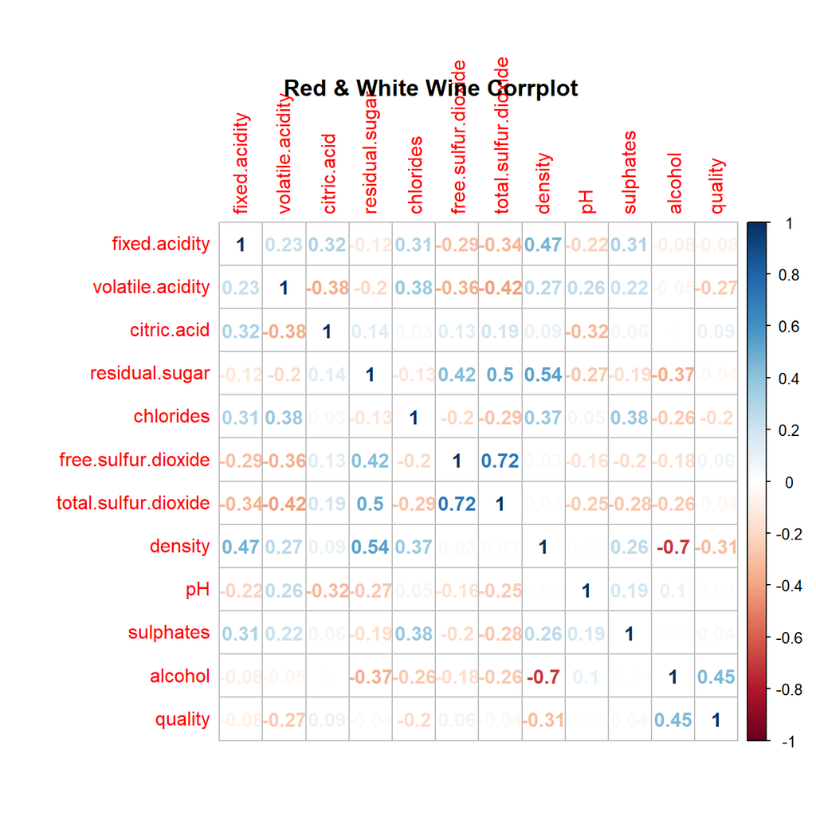

```r
corr = cor(VinoRB_filtered[,1:12])
corrplot(corr, method = "number")
title("Red & White Wine Corrplot", line = 0)
```

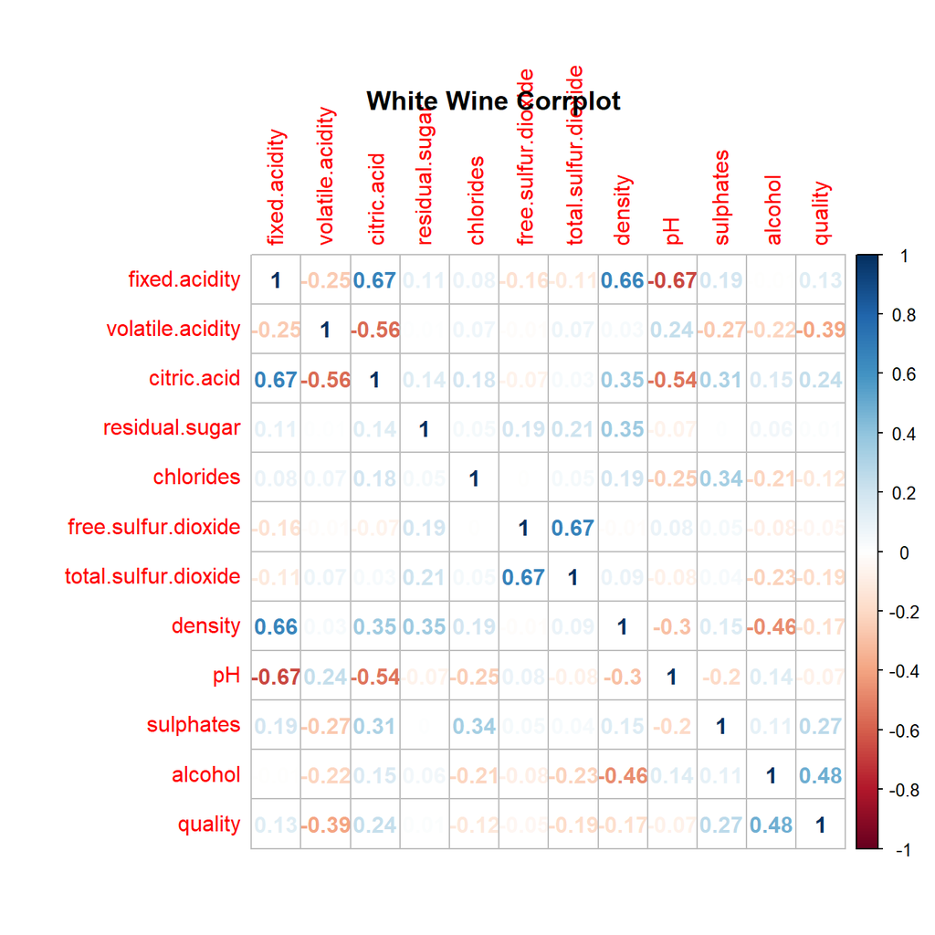

```r
corr = cor(VinoRB_filtered[which(VinoRB_filtered$Type=="B"),1:12])
corrplot(corr, method = "number")
title("White Wine Corrplot", line = 0)
```

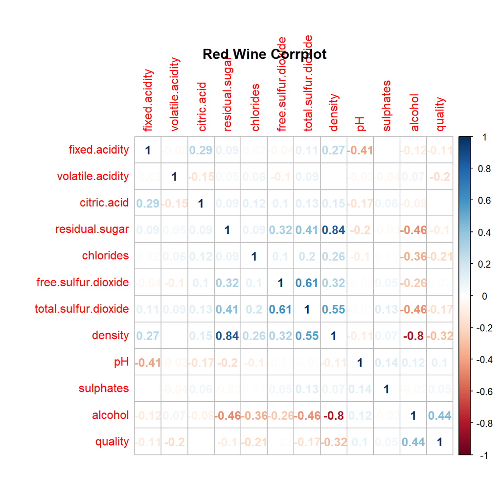

```r
corr = cor(VinoRB_filtered[which(VinoRB_filtered$Type=="R"),1:12])
corrplot(corr, method = "number")
title("Red Wine Corrplot", line = 0)
```

# 4 Arboles de Decisión - Reglas de Clasificación

En este paso intentaremos aplicar algoritmos de árboles de decisión que contienen componentes de regresión para entender las reglas de clasificación que hacen un vino de calidad. Usaremos varios algoritmos y los compararemos entre si.

## 4.1 Arbol de Decisión C5.0

Puesto que queremos tener menos atributos factoriales para comenzar con un árbol simple de C5.0 y comparar con CART vamos a discretizar la variable calidad por igual amplitud.

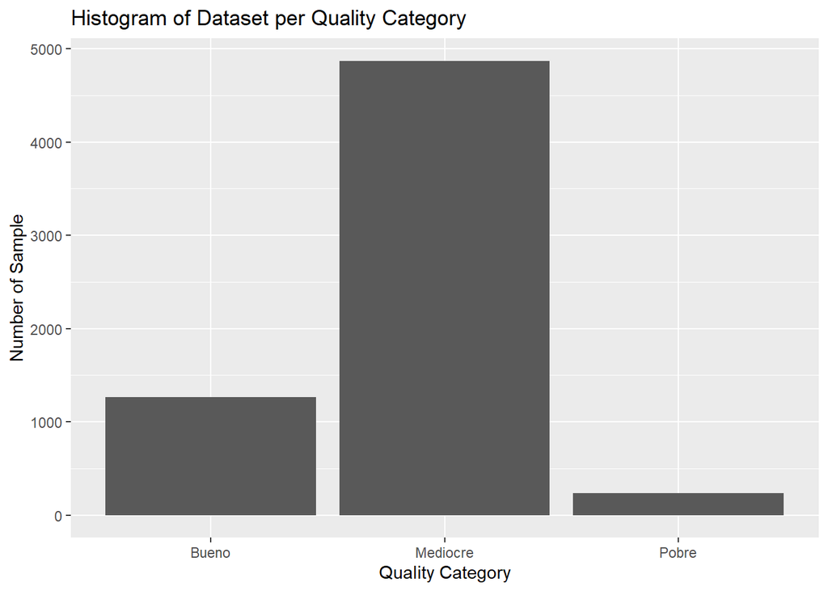

```r
VinoRB_filtered$qualitydisc <- arules::discretize(VinoRB_filtered$quality, method = "interval", breaks = 3, labels = FALSE)

VinoRB_filtered[which(VinoRB_filtered$qualitydisc =="1"), 14] <-"Pobre"
VinoRB_filtered[which(VinoRB_filtered$qualitydisc =="2"), 14] <-"Mediocre"
VinoRB_filtered[which(VinoRB_filtered$qualitydisc =="3"), 14] <-"Bueno"


ggplot(data.frame(VinoRB_filtered$qualitydisc), aes(x=VinoRB_filtered$qualitydisc)) +  geom_bar() + ggtitle("Histogram of Dataset per Quality Category") + xlab("Quality Category") + ylab("Number of Sample")
```

Sin embargo, podemos ver que la cantidad de Vinos de Calidad Inferior (o pobre) son mucho menos comparados a los de la calidad superior (o Bueno).

Por lo tanto, a la hora de partir los datos en train y test, (aunque en parte sea de forma aleatoria al haberlos desordenado) queremos asegurarnos de que no eliminamos una categoría por completo

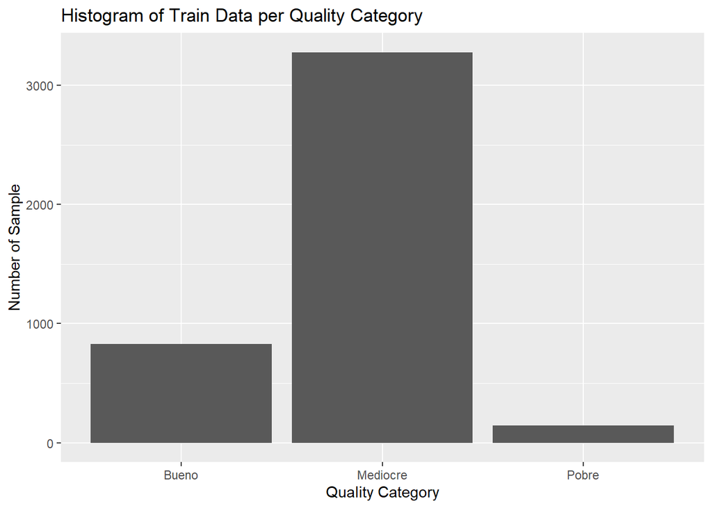

```r
VinoRB_filtered$qualitydisc<-as.factor(VinoRB_filtered$qualitydisc)


X <- VinoRB_filtered[-c(12,13,14)]
y <- VinoRB_filtered[14]

set.seed(666)
indexes = sample(1:nrow(VinoRB_filtered), size=floor((2/3)*nrow(VinoRB_filtered)))

trainX<-X[indexes,]
trainy<-y[indexes,]
testX<-X[-indexes,]
testy<-y[-indexes,]


ggplot(data.frame(trainy), aes(x=trainy)) +  geom_bar()+ ggtitle("Histogram of Train Data per Quality Category") + xlab("Quality Category") + ylab("Number of Sample")
```

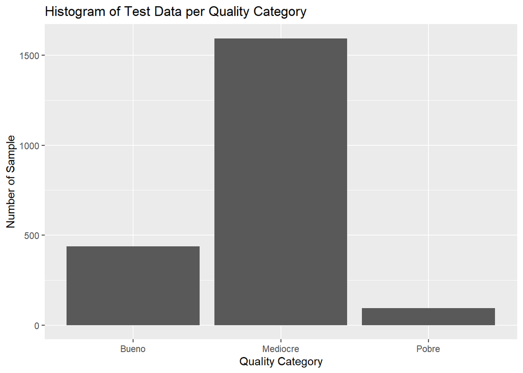

```r
ggplot(data.frame(testy), aes(x=testy)) +  geom_bar() + ggtitle("Histogram of Test Data per Quality Category")+ xlab("Quality Category")+ ylab("Number of Sample")
```

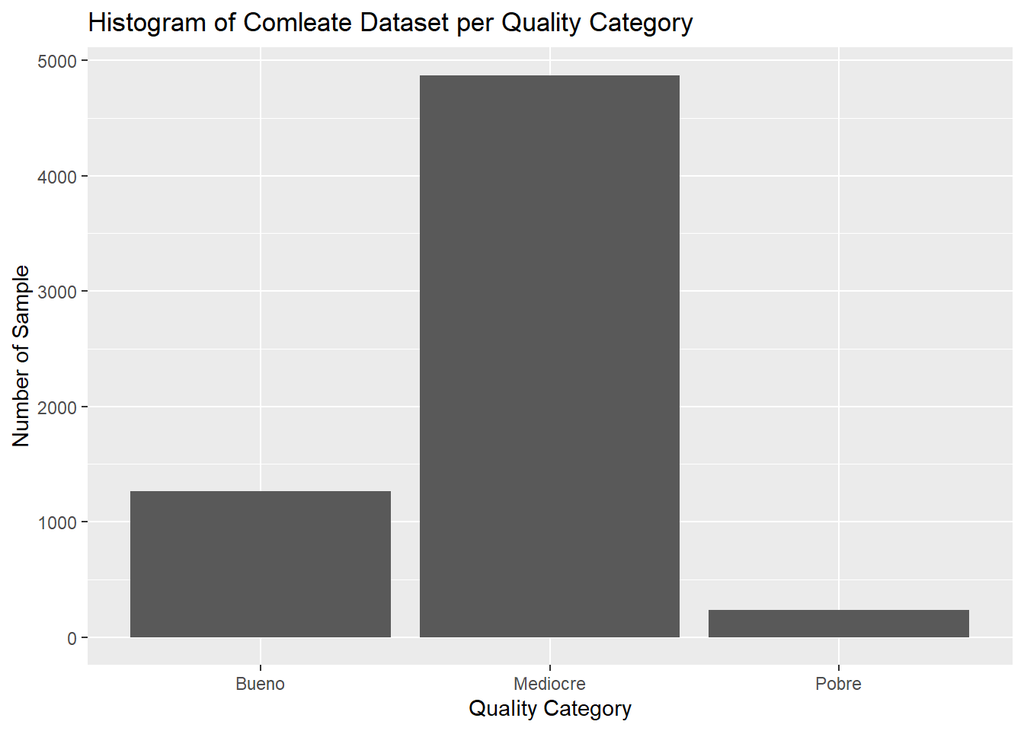

```r
ggplot(data.frame(VinoRB_filtered$qualitydisc), aes(x=VinoRB_filtered$qualitydisc)) +  geom_bar() + ggtitle("Histogram of Comleate Dataset per Quality Category") + xlab("Quality Category") + ylab("Number of Sample")
```

Como vemos en el grafico anterior no lo eliminamos ya que tendremos las mismas proporciones que en el dateset original

Se crea el árbol de decisión usando los datos de entrenamiento y se muestra por pantalla.

```r
model_Vino <- C50::C5.0(trainX, trainy)


summary(model_Vino)
```

```
##
## Call:
## C5.0.default(x = trainX, y = trainy)
##
##
## C5.0 [Release 2.07 GPL Edition]      Tue Jun 09 19:39:44 2020
## -------------------------------
##
## Class specified by attribute `outcome'
##
## Read 4248 cases (12 attributes) from undefined.data
##
## Decision tree:
##
## alcohol > 10.6:
## :...volatile.acidity > 0.53:
## :   :...volatile.acidity > 0.875:
## :   :   :...volatile.acidity <= 0.98: Mediocre (9/2)
## :   :   :   volatile.acidity > 0.98: Pobre (5)
## :   :   volatile.acidity <= 0.875:
## :   :   :...residual.sugar <= 1.25:
## :   :       :...volatile.acidity <= 0.655: Pobre (3)
## :   :       :   volatile.acidity > 0.655: Bueno (3/1)
## :   :       residual.sugar > 1.25:
## :   :       :...sulphates <= 0.65: Mediocre (96/11)
## :   :           sulphates > 0.65:
## :   :           :...citric.acid <= 0.61: Mediocre (54/11)
## :   :               citric.acid > 0.61: Bueno (3)
## :   volatile.acidity <= 0.53:
## :   :...alcohol > 12.75:
## :       :...chlorides > 0.068: Mediocre (6)
## :       :   chlorides <= 0.068:
## :       :   :...pH <= 3.04:
## :       :       :...volatile.acidity <= 0.365: Mediocre (13/2)
## :       :       :   volatile.acidity > 0.365: Bueno (5)
## :       :       pH > 3.04:
## :       :       :...residual.sugar > 3: Bueno (53/4)
## :       :           residual.sugar <= 3:
## :       :           :...fixed.acidity <= 5.5: Bueno (17)
## :       :               fixed.acidity > 5.5:
```

[output cut: 261 more lines]

```
##
##  100.00% volatile.acidity
##  100.00% alcohol
##   66.13% free.sulfur.dioxide
##   56.00% sulphates
##   50.33% citric.acid
##   47.36% fixed.acidity
##   43.53% residual.sugar
##   37.36% pH
##   24.20% chlorides
##   15.44% total.sulfur.dioxide
##   10.73% density
##
##
## Time: 0.0 secs
```

```r
plot(model_Vino, type="simple", main="C5.0 Tree")
```

[figure not shown]

Podemos ver en el summary que el porcentaje de error es de 14.6%, es decir que aun con este árbol hay 14% de vinos que se clasifican mal. También podemos ver en el summary que la capacidad de clasificar los vinos pobres correctamente es la peor de todas. Mas específicamente vemos que 92 vinos de los 147 calificados como malos por los catadores son clasificados como mediocres por el árbol.

En el grafico podemos ver que el tamaño del árbol es muy grande y es difícil entender las reglas que sigue para clasificar. Aun así, en las primeras ramas podemos ver que el nodo raíz es el alcohol y el siguiente nodo interno es la Volatile acidity.

Data la gran dimensión del árbol procederemos a analizarlo por partes de esta manera si tenemos en cuenta el alcohol menor que 10.7 y la volatile acidity mayor que 0.26 podemos dibujar el árbol debajo (es decir el nodo 90):

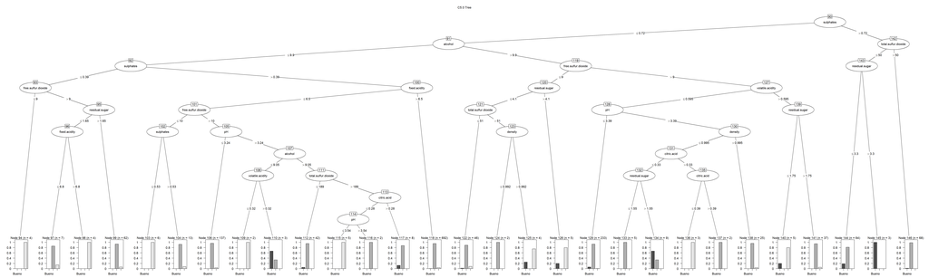

```r
myTree2 <- C50:::as.party.C5.0(model_Vino)

plot(myTree2[90], main="C5.0 Tree")
```

Al dibujar este árbol vemos mejor las reglas que se siguen posteriormente. Por ejemplo, podemos ver que guando el alcohol es menos de 10.7, la volátiles acidez es mayor que 0.26 y la total surfur dioxide es mayor que 50 vemos que obtenemos vinos mayoritariamente mediocres.

En cambio, cuando total surfur dioxide es menor que 50 y residual sugar es mayor que 33 obtenemos vinos buenos

También, fijándonos en el nodo 91 vemos que un alcohol de menos de 9.9 prácticamente en todos los casos indica vinos mediocres y malos

A continuación, también vamos a analizar la parte derecha del árbol más bien el nodo 226

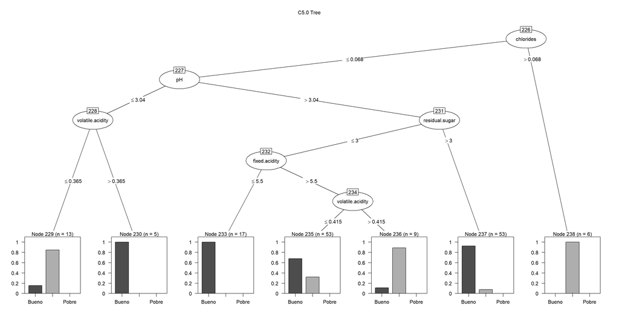

```r
plot(myTree2[226], main="C5.0 Tree")
```

Este nodo corresponde a las condiciones cuando el alcohol es mayor de 12.75 grados y la volatile acidity es menor que 0.53

Podemos ver que el hecho de que bajo las condiciones escritas en la frase superior la condición de Chlorides menor que 0.068 es necesarias para poder obtener vinos buenos.

Aparte cuando el ph es mayor que 3.04 y el residual sugar es mayor que 3 obtenemos vinos mejores

Cuando el PH es menor que 3.04 la volátiles acidez tiene que se mayor a 0.36 para obtener vinos mejores.

Obviamente el árbol siendo de más de 100 nodos va a ser muy difícil analizar cada caso específico dado los límites de tiempo en esta PEC, pero podríamos hacerlo si esto fuera necesario mirando sub arboles de los nodos internos tal y como he demostrado anteriormente.

Seguidamente vamos a medir la capacidad de predecir del modelo con los datos test y calcular la precisión de predicción del modelo con nuevos datos.

```r
predicted_model <- predict( model_Vino, testX, type="class" )


print(sprintf("La precisión del árbol es: %.4f %%",100*sum(predicted_model == testy) / length(predicted_model)))
```

```
## [1] "La precisión del árbol es: 76.3183 %"
```

Podemos ver que la precisión de clasificar correctamente los vinos es de 76.31%.

Seguidamente analizamos la matriz de precisión de clasificación por categorías de calidad.

```r
CrossTable(testy, predicted_model,prop.chisq  = FALSE, prop.c = FALSE, prop.r =FALSE,dnn = c('Reality', 'Prediction'))
```

```
##
##
##    Cell Contents
## |-------------------------|
## |                       N |
## |         N / Table Total |
## |-------------------------|
##
##
## Total Observations in Table:  2124
##
##
##              | Prediction
##      Reality |     Bueno |  Mediocre |     Pobre | Row Total |
## -------------|-----------|-----------|-----------|-----------|
##        Bueno |       125 |       311 |         1 |       437 |
##              |     0.059 |     0.146 |     0.000 |           |
## -------------|-----------|-----------|-----------|-----------|
##     Mediocre |        83 |      1486 |        25 |      1594 |
##              |     0.039 |     0.700 |     0.012 |           |
## -------------|-----------|-----------|-----------|-----------|
##        Pobre |         5 |        78 |        10 |        93 |
##              |     0.002 |     0.037 |     0.005 |           |
## -------------|-----------|-----------|-----------|-----------|
## Column Total |       213 |      1875 |        36 |      2124 |
## -------------|-----------|-----------|-----------|-----------|
##
##
```

Una vez más podemos ver que la capacidad de clasificar correctamente los vinos pobres es prácticamente nula. Mientras que solo el ~1/4% de los vinos buenos son clasificados correctamente el resto son asociados a los vinos mediocres.

## 4.2 Arbol de Decisión C5.0 - Mejora de Precisión

```r
rm(df)
df <- data.frame()
for (i in 1:100) {
  model10 <- C50::C5.0(trainX, trainy, trials = i)
  predicted_model10 <- predict(model10, testX, type="class")
  df <- rbind(df, data.frame(100*sum(predicted_model10 == testy) / length(predicted_model10), i))

}


colnames(df) <- c("Percentage", "Runs")

maxdf <- df[order(df[,1], decreasing = TRUE),][1:5,]
maxdf
```

```
##    Percentage Runs
## 23   83.19209   23
## 14   83.09793   14
## 21   83.09793   21
## 56   83.09793   56
## 16   83.05085   16
```

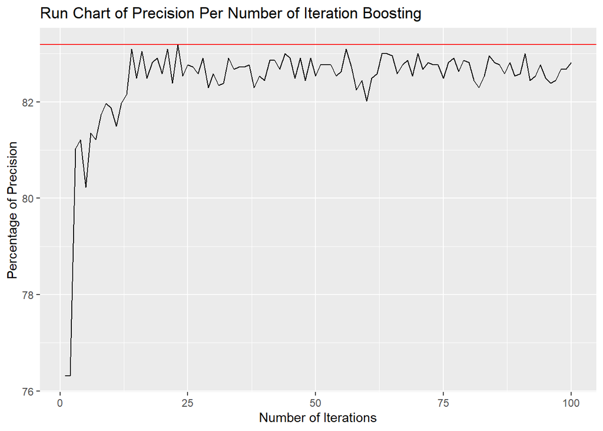

```r
ggplot() + geom_line(aes(y = Percentage, x = Runs), data = df)+  geom_hline(yintercept = max(df$Percentage, na.rm=TRUE), color="red") + geom_point()+ ggtitle("Run Chart of Precision Per Number of Iteration Boosting") + xlab("Number of Iterations") + ylab("Percentage of Precision")
```

Como podemos ver en la lista anterior no hay una relación única entre el número de iteraciones y la precisión. Sin embargo, queda probado que con varias iteraciones se obtiene mejores resultados en cuanto a la precisión.

El punto máximo de precisión estaría por entorno a las 20-26 iteraciones (23 en la ultima iteracion), pero aun así este número varia por ejecución, lo que no varía es la gráfica que presenta una función de tipo logarítmico indicando que las mayores mejoras de precisión se consiguen subiendo de 0 a 25 el número de iteraciones en boosting.

Por lo que se comenta en la frase anteriormente vamos a usar las variables del punto máximo de precisión para calcular la tabla de precisión de clasificación por clases de calidad. No usaremos un numero ya que el máximo varía dependiendo de la ejecución.

```r
predicted_model20 <- predict( C50::C5.0(trainX, trainy, trials = maxdf[1,2]), testX, type="class" )

CrossTable(testy, predicted_model20, prop.chisq  = FALSE, prop.c = FALSE, prop.r =FALSE,dnn = c('Reality', 'Prediction'))
```

```
##
##
##    Cell Contents
## |-------------------------|
## |                       N |
## |         N / Table Total |
## |-------------------------|
##
##
## Total Observations in Table:  2124
##
##
##              | Prediction
##      Reality |     Bueno |  Mediocre |     Pobre | Row Total |
## -------------|-----------|-----------|-----------|-----------|
##        Bueno |       248 |       189 |         0 |       437 |
##              |     0.117 |     0.089 |     0.000 |           |
## -------------|-----------|-----------|-----------|-----------|
##     Mediocre |        75 |      1515 |         4 |      1594 |
##              |     0.035 |     0.713 |     0.002 |           |
## -------------|-----------|-----------|-----------|-----------|
##        Pobre |         0 |        89 |         4 |        93 |
##              |     0.000 |     0.042 |     0.002 |           |
## -------------|-----------|-----------|-----------|-----------|
## Column Total |       323 |      1793 |         8 |      2124 |
## -------------|-----------|-----------|-----------|-----------|
##
##
```

En la matriz superior podemos ver que de nuevo el modelo no es capaz de identificar los vinos pobres o inferiores. lo que sí que sería más capaz es de identificar los vinos buenos con una mejora en la precisión antes de hacer el boosting.

## 4.3 Arbol de Decisión CART

Vamos a probar con el algoritmo CART y ver si nos mejora la precisión. Primero aplicamos el algoritmo y enseñamos el árbol que se obtiene.

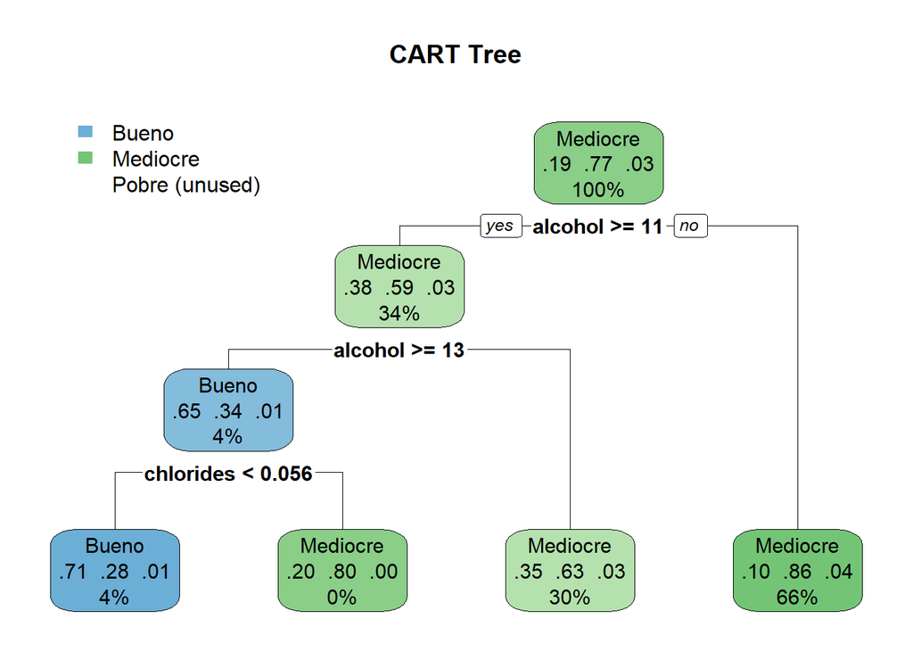

```r
Modelo_Vino_CART<- rpart(trainy~., data = trainX, method = 'class')


rpart.plot(Modelo_Vino_CART, main="CART Tree")
```

Podemos ver en la gráfica anterior que el árbol es muchísimo más simple. Así podemos ver que el alcohol mayor de 13 grados y unos “Chlorides” menores de 0.056 obtenemos vinos buenos. Por el contrario, el resto son vinos mediocres

Por este motivo calculamos la precisión y la matriz de precisión por categoría de calidad

```r
predict_CART <- predict( Modelo_Vino_CART, testX,  type="class")

table(testy, predict_CART)
```

```
##           predict_CART
## testy      Bueno Mediocre Pobre
##   Bueno       53      384     0
##   Mediocre    28     1566     0
##   Pobre        1       92     0
```

```r
caret::confusionMatrix(table(predict_CART, testy))
```

```
## Confusion Matrix and Statistics
##
##             testy
## predict_CART Bueno Mediocre Pobre
##     Bueno       53       28     1
##     Mediocre   384     1566    92
##     Pobre        0        0     0
##
## Overall Statistics
##
##                Accuracy : 0.7622
##                  95% CI : (0.7435, 0.7802)
##     No Information Rate : 0.7505
##     P-Value [Acc > NIR] : 0.1092
##
##                   Kappa : 0.1212
##
##  Mcnemar's Test P-Value : <2e-16
##
## Statistics by Class:
##
##                      Class: Bueno Class: Mediocre Class: Pobre
## Sensitivity               0.12128          0.9824      0.00000
## Specificity               0.98281          0.1019      1.00000
## Pos Pred Value            0.64634          0.7669          NaN
## Neg Pred Value            0.81195          0.6585      0.95621
## Prevalence                0.20574          0.7505      0.04379
## Detection Rate            0.02495          0.7373      0.00000
## Detection Prevalence      0.03861          0.9614      0.00000
## Balanced Accuracy         0.55205          0.5422      0.50000
```

Seguidamente vemos que la overall accuracy es de 76.2 % que es no mejor que el algoritmo de C5.0 ni tampoco mejor que el C5.0 boosted.

Al mismo tempo podemos ver que el árbol del CART es muchísimo más simple y nos servirá a la hora de entender las reglas mucho mejor que el C5.0. (por ejemplo, si queremos entrenar a un humano a hacer la clasificación)

## 4.4 Superposición de Arboles con Random Forest

El algoritmo de Random Forest funciona agregado las predicciones hechas por múltiples arboles de decisión a distintos niveles de profundidad de esta manera primero vamos a crear el modelo y testear la precisión

```r
model_forest <- randomForest(trainy ~ ., data = trainX)
str(getTree(model_forest, 3, labelVar=TRUE))
```

```
## 'data.frame':    1083 obs. of  6 variables:
##  $ left daughter : num  2 4 6 8 10 12 14 16 18 20 ...
##  $ right daughter: num  3 5 7 9 11 13 15 17 19 21 ...
##  $ split var     : Factor w/ 11 levels "alcohol","chlorides",..: 4 7 9 1 11 4 2 2 11 11 ...
##  $ split point   : num  0.993 3.295 0.675 12.45 0.245 ...
##  $ status        : num  1 1 1 1 1 1 1 1 1 1 ...
##  $ prediction    : chr  NA NA NA NA ...
```

```r
head(getTree(model_forest, 3, labelVar=TRUE),10)
```

```
##    left daughter right daughter        split var split point status
## 1              2              3          density    0.992650      1
## 2              4              5               pH    3.295000      1
## 3              6              7        sulphates    0.675000      1
## 4              8              9          alcohol   12.450000      1
## 5             10             11 volatile.acidity    0.245000      1
## 6             12             13          density    0.995185      1
## 7             14             15        chlorides    0.031500      1
## 8             16             17        chlorides    0.038500      1
## 9             18             19 volatile.acidity    0.325000      1
## 10            20             21 volatile.acidity    0.175000      1
##    prediction
## 1        <NA>
## 2        <NA>
## 3        <NA>
## 4        <NA>
## 5        <NA>
## 6        <NA>
## 7        <NA>
## 8        <NA>
## 9        <NA>
## 10       <NA>
```

```r
pred_forest <- predict(model_forest, newdata = testX)

confusionMatrix(pred_forest, testy)
```

```
## Confusion Matrix and Statistics
##
##           Reference
## Prediction Bueno Mediocre Pobre
##   Bueno      243       67     1
##   Mediocre   194     1522    85
##   Pobre        0        5     7
##
## Overall Statistics
##
##                Accuracy : 0.8343
##                  95% CI : (0.8178, 0.8499)
##     No Information Rate : 0.7505
##     P-Value [Acc > NIR] : < 2.2e-16
##
##                   Kappa : 0.5027
##
##  Mcnemar's Test P-Value : < 2.2e-16
##
## Statistics by Class:
##
##                      Class: Bueno Class: Mediocre Class: Pobre
## Sensitivity                0.5561          0.9548     0.075269
## Specificity                0.9597          0.4736     0.997538
## Pos Pred Value             0.7814          0.8451     0.583333
## Neg Pred Value             0.8930          0.7771     0.959280
## Prevalence                 0.2057          0.7505     0.043785
## Detection Rate             0.1144          0.7166     0.003296
## Detection Prevalence       0.1464          0.8479     0.005650
## Balanced Accuracy          0.7579          0.7142     0.536403
```

```r
mean(pred_forest == testy)
```

```
## [1] 0.834275
```

# 5 Algoritmo supervisado KNN

## 5.1 KNN sin PCA

Dividimos el dataset en train y test

```r
X <- VinoRB_filtered[-c(12,13,14)]
y <- VinoRB_filtered[14]


set.seed(666)
indexes = sample(1:nrow(VinoRB_filtered), size=floor((2/3)*nrow(VinoRB_filtered)))

trainX<-X[indexes,]
trainy<-y[indexes,]
testX<-X[-indexes,]
testy<-y[-indexes,]
```

aplicamos el knn y guardamos los resultados de la precision en un dataframe

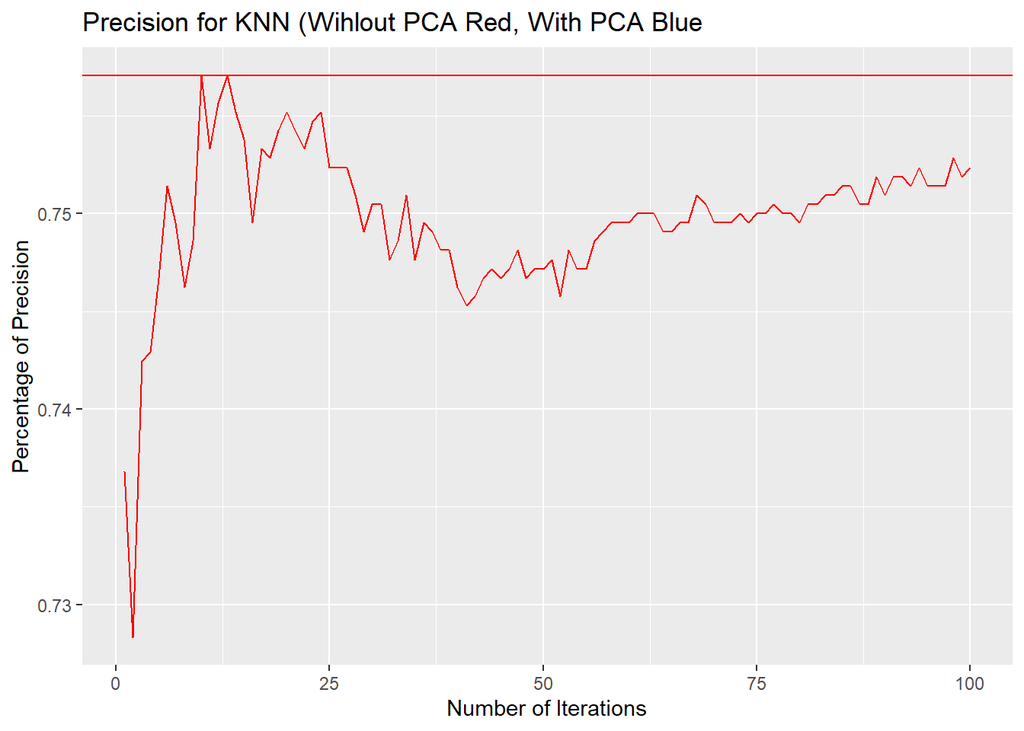

```r
precisionknndf <- data.frame()

for (i in 1:100) {
  modelknn <- knn(trainX,testX,trainy,k = i)
  precisionknn <- 1-sum(modelknn!=testy)/length(testy)
  precisionknndf <- rbind(precisionknndf, data.frame(precisionknn, i))

}

colnames(precisionknndf) <- c("Percentage", "Runs")

max<- data.frame(Type=rep("", 2),Precision=rep(NA, 2),  # as many cols as you need
                 stringsAsFactors=FALSE)

max[1,] <- list("KnnWithoutPCA", precisionknndf[order(precisionknndf[,1], decreasing = TRUE),][1,1])

colnames(max) <- c("Type", "Precision")


p <- ggplot() + geom_line(aes(y = Percentage, x = Runs), data = precisionknndf, color = "red")+  geom_hline(yintercept = max(precisionknndf$Percentage, na.rm=TRUE), color="red") + geom_point()+ ggtitle("Precision for KNN (Wihlout PCA Red, With PCA Blue") + xlab("Number of Iterations") + ylab("Percentage of Precision")

p
```

## 5.2 KNN con PCA

En este apartado vamos a hacer el análisis de componentes.

Primero de todo estandarizamos los datos

```r
VinoRB_filtered_scaled <- scale(VinoRB_filtered[1:11],apply(VinoRB_filtered[1:11],2,mean) ,apply(VinoRB_filtered[1:11],2,sd) )
summary(VinoRB_filtered_scaled)
```

```
##  fixed.acidity     volatile.acidity   citric.acid       residual.sugar
##  Min.   :-2.5849   Min.   :-1.5859   Min.   :-2.23067   Min.   :-1.0304
##  1st Qu.:-0.6405   1st Qu.:-0.6689   1st Qu.:-0.48361   1st Qu.:-0.7753
##  Median :-0.1738   Median :-0.3021   Median :-0.06431   Median :-0.5202
##  Mean   : 0.0000   Mean   : 0.0000   Mean   : 0.00000   Mean   : 0.0000
##  3rd Qu.: 0.3706   3rd Qu.: 0.3704   3rd Qu.: 0.49475   3rd Qu.: 0.5641
##  Max.   : 6.7483   Max.   : 7.5845   Max.   : 6.36487   Max.   : 5.5601
##    chlorides       free.sulfur.dioxide total.sulfur.dioxide
##  Min.   :-1.3636   Min.   :-1.69368    Min.   :-1.94951
##  1st Qu.:-0.5222   1st Qu.:-0.77754    1st Qu.:-0.67338
##  Median :-0.2611   Median :-0.09044    Median : 0.05331
##  Mean   : 0.0000   Mean   : 0.00000    Mean   : 0.00000
##  3rd Qu.: 0.2612   3rd Qu.: 0.59667    3rd Qu.: 0.70910
##  Max.   :16.1025   Max.   : 6.63746    Max.   : 4.44001
##     density               pH             sulphates          alcohol
##  Min.   :-2.56510   Min.   :-2.18174   Min.   :-2.1044   Min.   :-2.0926
##  1st Qu.:-0.80930   1st Qu.:-0.71264   1st Qu.:-0.6803   1st Qu.:-0.8315
##  Median : 0.07029   Median :-0.04487   Median :-0.1379   Median :-0.1588
##  Mean   : 0.00000   Mean   : 0.00000   Mean   : 0.0000   Mean   : 0.0000
##  3rd Qu.: 0.78073   3rd Qu.: 0.68967   3rd Qu.: 0.4724   3rd Qu.: 0.6820
##  Max.   : 5.28016   Max.   : 2.82653   Max.   : 9.8303   Max.   : 3.7088
```

Una vez estandarizados procedemos a efectuar el analisis de componentes PCA.

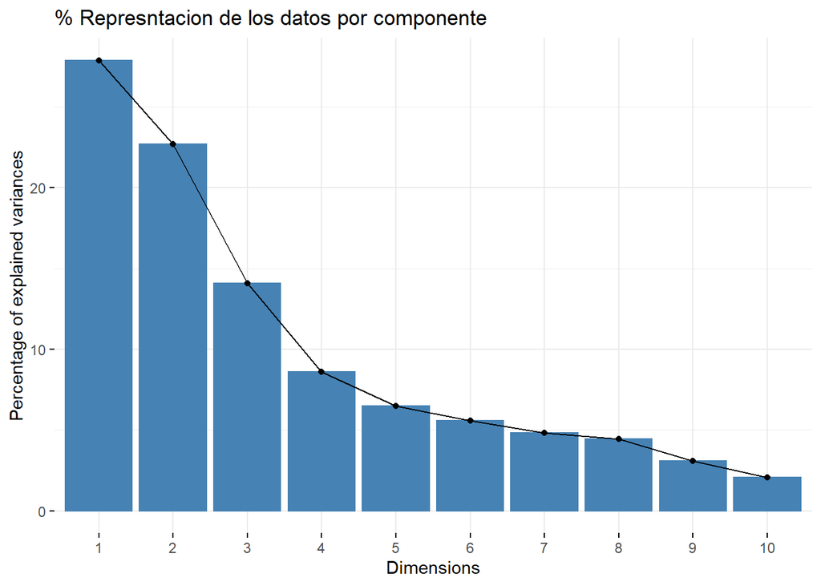

```r
PCA <- princomp(VinoRB_filtered_scaled, scale=TRUE)

fviz_eig(PCA) + labs(title ="% Represntacion de los datos por componente ")
```

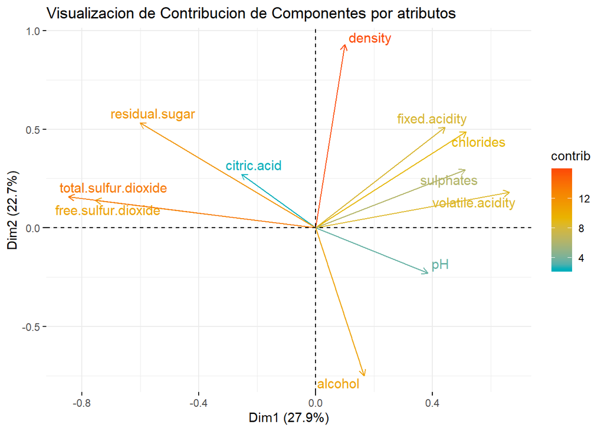

```r
fviz_pca_var(PCA,
             col.var = "contrib", # Color by contributions to the PC
             gradient.cols = c("#00AFBB", "#E7B800", "#FC4E07"),
             repel = TRUE     # Avoid text overlapping
             ) + labs(title ="Visualizacion de Contribucion de Componentes por atributos ")
```

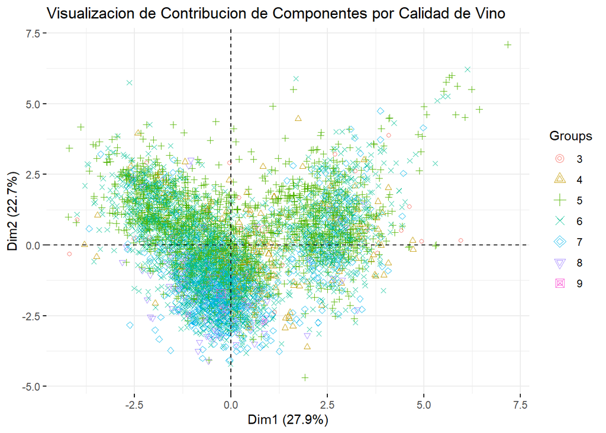

```r
fviz_pca_ind(PCA, label="none", habillage=VinoRB_filtered$quality) +
  labs(title ="Visualizacion de Contribucion de Componentes por Calidad de Vino ")
```

En la tercera figura fig 3 podemos ver la correlación entre los principales componentes 1 y dos y la calidad de los vinos. De esta manera vemos que los vinos de mayor calidad se situarían en la parte inferior inzquierda de la gráfica. Esto demostraría que nuestros componentes serian relativamente buenos diferenciado los vinos buenos de los malos.

Seguidamente aplicamos el knn usando las 4 primeras componentes del PCA ya que esta explicaría la mayoría de la variación

```r
precisionknndfPCA <- data.frame()

components <- PCA$scores
component1 <- -1*components[,1]
component2 <- -1*components[,2]
component3 <- -1*components[,3]
component4 <- -1*components[,4]
newX = cbind(component1, component2, component3, component4)
PCAtrainX<-newX[indexes,]
trainy<-y[indexes,]
PCAtestX<-newX[-indexes,]
testy<-y[-indexes,]

for (i in 1:100) {
  modelknnPCA <- knn(PCAtrainX,PCAtestX,trainy,k = i)
  precisionknn <- 1-sum(modelknnPCA!=testy)/length(testy)
  precisionknndfPCA <- rbind(precisionknndfPCA, data.frame(precisionknn, i))

}


confusionMatrix(modelknnPCA, testy )
```

```
## Confusion Matrix and Statistics
##
##           Reference
## Prediction Bueno Mediocre Pobre
##   Bueno       40       37     0
##   Mediocre   397     1557    93
##   Pobre        0        0     0
##
## Overall Statistics
##
##                Accuracy : 0.7519
##                  95% CI : (0.7329, 0.7701)
##     No Information Rate : 0.7505
##     P-Value [Acc > NIR] : 0.4518
##
##                   Kappa : 0.0786
##
##  Mcnemar's Test P-Value : NA
##
## Statistics by Class:
##
##                      Class: Bueno Class: Mediocre Class: Pobre
## Sensitivity               0.09153         0.97679      0.00000
## Specificity               0.97807         0.07547      1.00000
## Pos Pred Value            0.51948         0.76063          NaN
## Neg Pred Value            0.80606         0.51948      0.95621
## Prevalence                0.20574         0.75047      0.04379
## Detection Rate            0.01883         0.73305      0.00000
## Detection Prevalence      0.03625         0.96375      0.00000
## Balanced Accuracy         0.53480         0.52613      0.50000
```

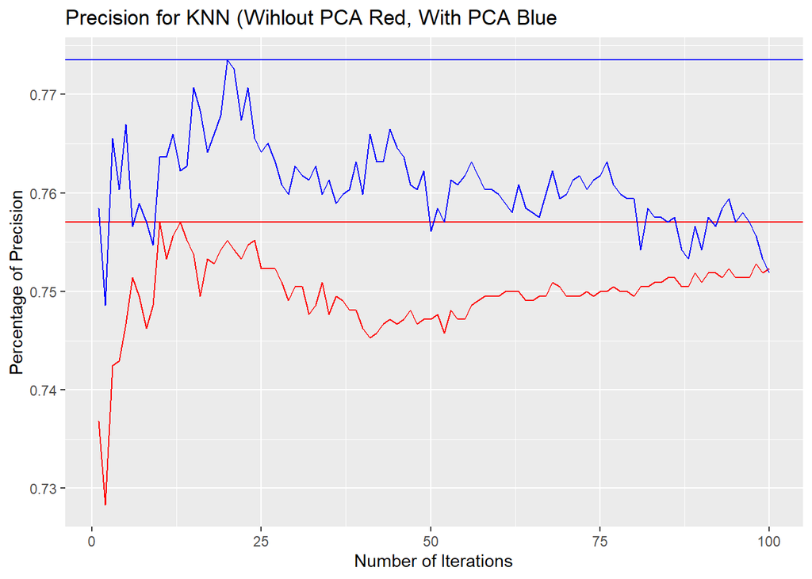

```r
colnames(precisionknndfPCA) <- c("Percentage", "Runs")


max[2,] <- list("KnnWithPCA",precisionknndfPCA[order(precisionknndfPCA[,1], decreasing = TRUE),][1,1])

p2 <- p + geom_line(aes(y = Percentage, x = Runs), data = precisionknndfPCA, color = "blue")+  geom_hline(yintercept = max(precisionknndfPCA$Percentage, na.rm=TRUE), color="blue") + geom_point()

p2
```

```r
max
```

```
##            Type Precision
## 1 KnnWithoutPCA 0.7570621
## 2    KnnWithPCA 0.7735405
```

Esto se debe a que el algoritmo sin PCA utiliza todas las variables para generar el modelo midiendo distancias mientras que el PCA genera nuevos vectores (haciendo una transformación lineal de los datos existentes y reduciendo la dimensionalidad) que expresan mejor la variación entre los puntos. De esta manera en términos de distancia los nuevos data points están más alejados entre los distintos tipos de vino.

# 6 Concusiones

Finalmente Concluimos que:

2.Durante la Creación del Modelo Predictivo. Hemos tenido la mejor precisión con el algoritmo de Arboles de decisión tipo C5.0 “Booseted” y Random Forest con una precisión de mas de 80% (Varia según la ejecución) para predecir los vinos según su clasificación original. Sin embargo la precisión es prácticamente nula a la hora de identificar vinos malos para el algoritmo C5.0 y muy baja para el Random Forest como se puede ver en las matrices de confusión. También cabe destacar que los árboles generados por C5.0 y Random Forest son extremadamente extensos y prácticamente son inútiles para sacar reglas de clasificación comprensibles.

3.Durante la Creación del Modelo Predictivo. Vemos que en cuanto a la precisión los algoritmos supervisados KNN y arboles de clasificación de tipo CART son inferiores al C5.0 y random forest con una precisión de entre 75 y 80 %. Tampoco son buenos a la hora de identificar vinos de mala calidad. Sin embargo, podemos ver que con el algoritmo CART generamos unas reglas de clasificación muy claras y comprensibles (como se ve en la gráfica “CARD Tree”) con las que podríamos fácilmente identificar vinos Buenos y Mediocres con tan solo midiendo 2 propiedades químicas (el alcohol y los clorhídricos). De esta manera abriendo la puerta para generar un dispositivo simple y barato de medición de la calidad del vino ya que no haría falta saber el resto de las propiedades químicas.